# Estudio sobre la fuga de clientes en una compañía telefónica

Hassan Chafi Xavier

1/2/2022

## Preparación del entorno de trabajo.

Para comenzar, voy a fijar el directorio de trabajo, cargo el archivo de las funciones y las librerías que usaré y realizo una lectura del archivo de los datos depurado que había guardado anteriormente.

```r
# Fijo el directorio de trabajo
setwd("C:/Users/96has/Documents/NTIC/6. Documentación minería de Datos y Modelización Predictiva-20211212")

#Cargo el archivo de funciones de R
source("Funciones_R.R")

#Cargo las librerías que usaré
paquetes(c('corrplot','caret','ggplot2', 'lmSupport', 'questionr','psych', 'caret', 'glmnet', 'epiDisplay', 'pROC', 'dplyr', 'kableExtra'))
```

```r
# Cargar el archivo de datos depurados
datos <- readRDS("C:/Users/96has/Documents/NTIC/6. Documentación minería de Datos y Modelización Predictiva-20211212/Tarea/datosTelefoniaDep.RDS")
```

Voy a realizar una breve inspección de los datos para revisar que no hayan sufrido ninguna alteración al cargarlos.

```r
# Observamos los detalles de las columnas del archivo de datos
str(datos)
```

```
## 'data.frame':    6353 obs. of  20 variables:
##  $ varObj         : Factor w/ 2 levels "0","1": 1 1 2 1 2 2 1 1 2 1 ...
##  $ Genero         : Factor w/ 2 levels "Female","Male": 1 2 2 2 1 1 2 1 2 2 ...
##  $ Mayor65        : Factor w/ 2 levels "0","1": 1 1 1 1 1 1 1 1 1 1 ...
##  $ Conyuge        : Factor w/ 2 levels "0","1": 2 1 1 1 1 1 1 1 2 1 ...
##  $ PersCargo      : Factor w/ 2 levels "0","1": 1 1 1 1 1 1 2 1 1 2 ...
##  $ Antig.fc.edad  : num  1 34 2 45 32.4 ...
##  $ Telf_serv      : Factor w/ 2 levels "0","1": 1 2 2 1 2 2 2 1 2 2 ...
##  $ VariasLineas   : Factor w/ 2 levels "0","1": 1 1 1 1 1 2 2 1 2 1 ...
##  $ Int_serv       : Factor w/ 3 levels "DSL","Fiber optic",..: 1 1 1 1 2 2 2 2 2 1 ...
##  $ Seguridad      : Factor w/ 2 levels "0","1": 1 2 2 2 1 1 1 2 1 2 ...
##  $ CopiaSeguridad : Factor w/ 2 levels "0","1": 2 1 2 1 1 1 2 1 1 2 ...
##  $ Antivirus_disp : Factor w/ 2 levels "0","1": 1 2 1 2 1 2 1 1 2 1 ...
##  $ Soporte_tecnico: Factor w/ 2 levels "0","1": 1 1 1 2 1 1 1 1 2 1 ...
##  $ TV_streaming   : Factor w/ 2 levels "0","1": 1 1 1 1 1 2 2 1 2 1 ...
##  $ Peliculas      : Factor w/ 2 levels "0","1": 1 1 1 1 1 2 1 1 2 1 ...
##  $ Contrato       : Factor w/ 3 levels "Month-to-month",..: 1 2 1 2 1 1 1 1 1 1 ...
##  $ Fact_sinPapel  : Factor w/ 2 levels "0","1": 2 1 2 1 2 2 2 1 2 1 ...
##  $ MetodoPago     : Factor w/ 4 levels "Bank transfer (automatic)",..: 3 4 4 3 3 3 2 4 3 3 ...
##  $ FacturaMes     : num  64.7 64.7 53.9 42.3 70.7 ...
##  $ FacturaTotal   : num  29.9 1889.5 108.2 1840.8 151.7 ...
```

```r
summary(datos)
```

```
##  varObj      Genero     Mayor65  Conyuge  PersCargo Antig.fc.edad   Telf_serv
##  0:4667   Female:2963   0:5397   0:3287   0:4439    Min.   : 0.00   0: 605
##  1:1686   Male  :3390   1: 956   1:3066   1:1914    1st Qu.:10.00   1:5748
##                                                     Median :32.00
##                                                     Mean   :32.38
##                                                     3rd Qu.:54.00
##                                                     Max.   :72.00
##  VariasLineas        Int_serv    Seguridad CopiaSeguridad Antivirus_disp
##  0:3687       DSL        :2122   0:4532    0:4180         0:4180
##  1:2666       Fiber optic:2892   1:1821    1:2173         1:2173
##               No         :1339
##
##
##
##  Soporte_tecnico TV_streaming Peliculas           Contrato    Fact_sinPapel
##  0:4509          0:3936       0:3902    Month-to-month:3679   0:2483
##  1:1844          1:2417       1:2451    One year      :1261   1:3870
##                                         Two year      :1413
##
##
##
##                      MetodoPago     FacturaMes      FacturaTotal
##  Bank transfer (automatic):1283   Min.   : 18.25   Min.   :  18.8
##  Credit card (automatic)  :1290   1st Qu.: 41.10   1st Qu.: 396.3
##  Electronic check         :2444   Median : 68.75   Median :1387.3
##  Mailed check             :1336   Mean   : 64.68   Mean   :2268.7
##                                   3rd Qu.: 89.00   3rd Qu.:3778.0
##                                   Max.   :118.75   Max.   :8672.5
```

## Separación de variable objetivo y variables predictoras y creación de variables aleatorias de control.

En este punto voy a separar la variable objetivo de los datos que contienen las variables predictoras para la automatización del proceso de transformación de las variables. También voy a crear dos variables aleatorias que tendrán una función de control para evaluar la influencia que tienen las variables predictoras sobre la respuesta; las variables predictoras con menor capacidad de discriminación que las variables aleatorias serán variables que no tendrán relevancia a la hora de explicar la variabilidad de la variable objetivo.

```r
# Separación de la variable objetivo de las variables predictoras
varObj <- datos$varObj
input <- datos[ , -1]
```

```r
# Creación de las variables aleatorias de control
input$aleatorio1 <- runif(nrow(input))
input$aleatorio2 <- runif(nrow(input))
```

## Análisis descriptivo sobre la relación entre pares de variables.

En este apartado se evaluará fundamentalmente la relación que tienen las variables predictoras sobre la variable objetivo.

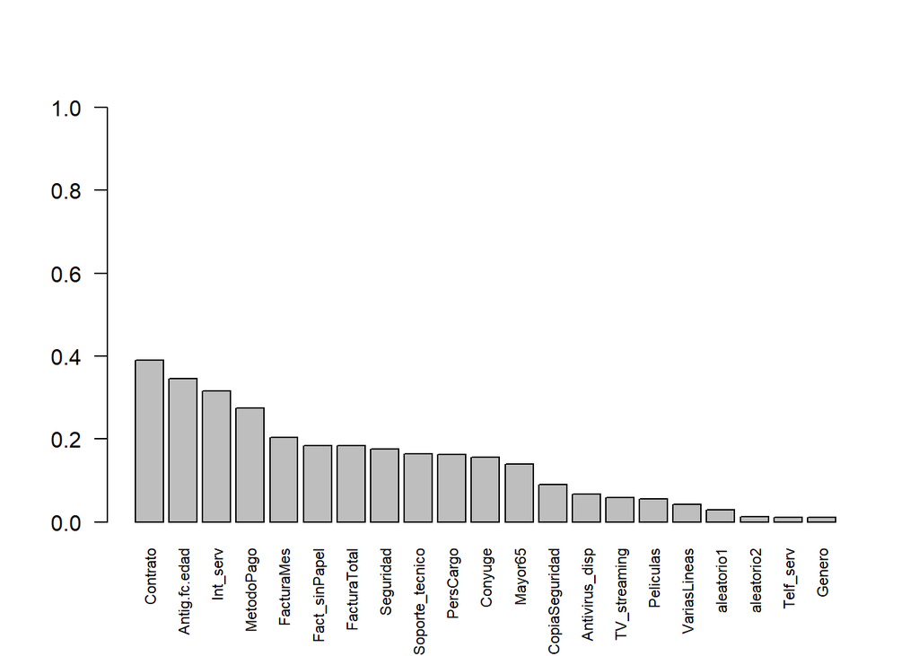

```r
# Evaluación sobre la importancia de las variables predictoras sobre la variable objetivo
graficoVcramer(input, varObj)
```

El gráfico V de Cramer revela un ranking de influencia de las variables predictoras sobre la variable objetivo. Las variables posicionadas por debajo de las dos variables aleatorias de control generadas, no tendrán la necesaria influencia sobre la variable objetivo para explicar su variabilidad, estas variables son: Telf_serv y Genero. De este modo, parece que las variables que más influyen en la variabilidad de la variable objetivo binaria **Fuga** son:

- Contrato
- Antig.fc.edad
- Int_serv
- MetodoPago
- FacturaMes

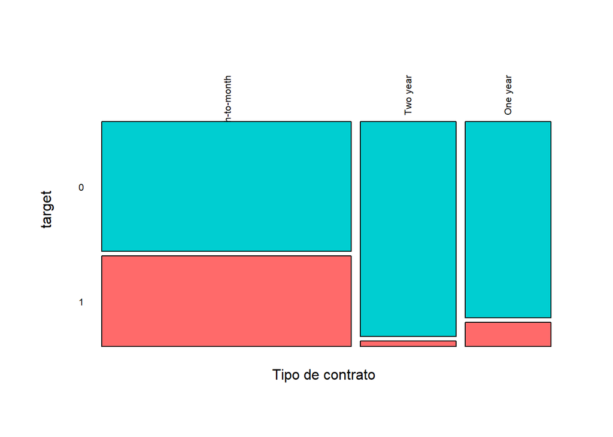

```r
#Analisis gráfico sobre la influencia de algunas variables categóricas sobre la variable objetivo
m1 <- mosaico_targetbinaria(input$Contrato, varObj, "Tipo de contrato") #Esta sí influye
```

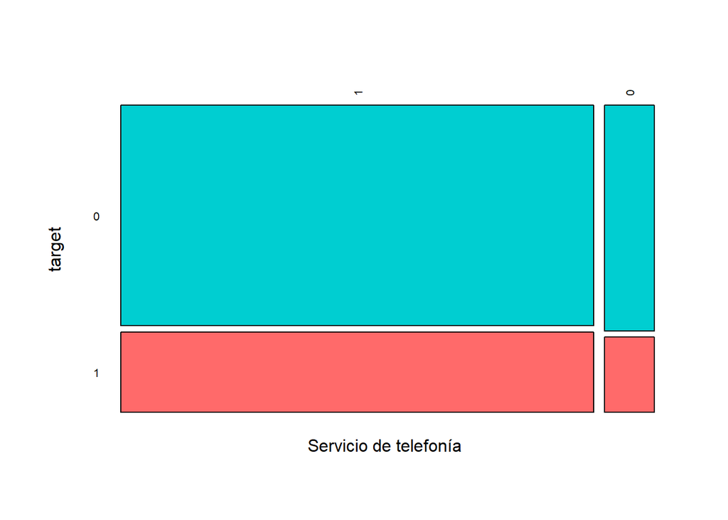

```r
m2 <- mosaico_targetbinaria(input$Telf_serv, varObj, "Servicio de telefonía") #Esta no influye
```

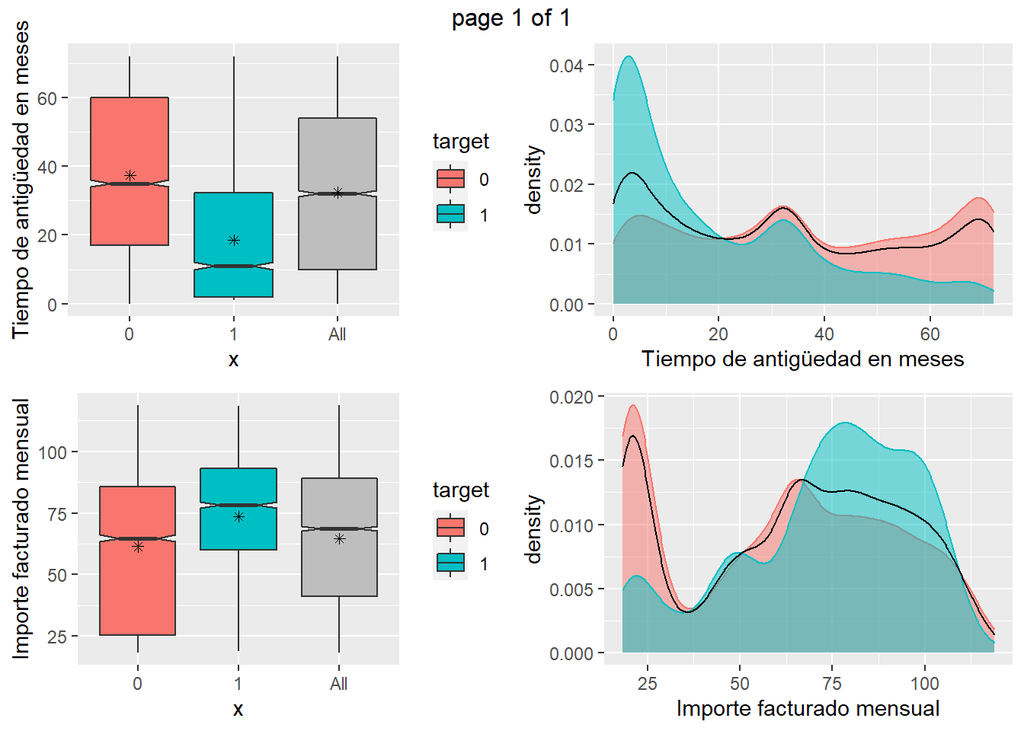

```r
#Analisis gráfico sobre la influencia de algunas variables continuas sobre la variable objetivo
bx1 <- boxplot_targetbinaria(input$Antig.fc.edad, varObj, "Tiempo de antigüedad en meses") #Esta sí influye
h1 <- hist_targetbinaria(input$Antig.fc.edad, varObj, "Tiempo de antigüedad en meses") #Esta sí influye
bx2 <- boxplot_targetbinaria(input$FacturaMes, varObj, "Importe facturado mensual") #Esta sí influye
h2 <- hist_targetbinaria(input$FacturaMes, varObj, "Importe facturado mensual") #Esta sí influye

gridExtra::marrangeGrob(list(bx1, bx2, h1, h2),nrow = 2,ncol=2)
```

## Transformación de las variables.

A continuación se transforman las variables predictoras continuas para maximizar la relación con la variable objetivo en sentido V de Cramer.

```r
# Se buscan las mejores transformaciones
input_obj <- cbind(input, Transf_Auto(Filter(is.numeric, input), varObj))

# Se guarda el dataset con las transformaciones
todo_obj <- data.frame(input_obj, varObj)
saveRDS(todo_obj, "transf_obj_Telefonia.RDS")
```

Ahora se comprueba si la influencia de las variables predictoras sobre la variable objetivo ha aumentado. Las variables que han podido mejorar su influencia sobre la variable objetivo son **Antig.fd.edad**, **FacturaMes** y **FacturaTotal**.

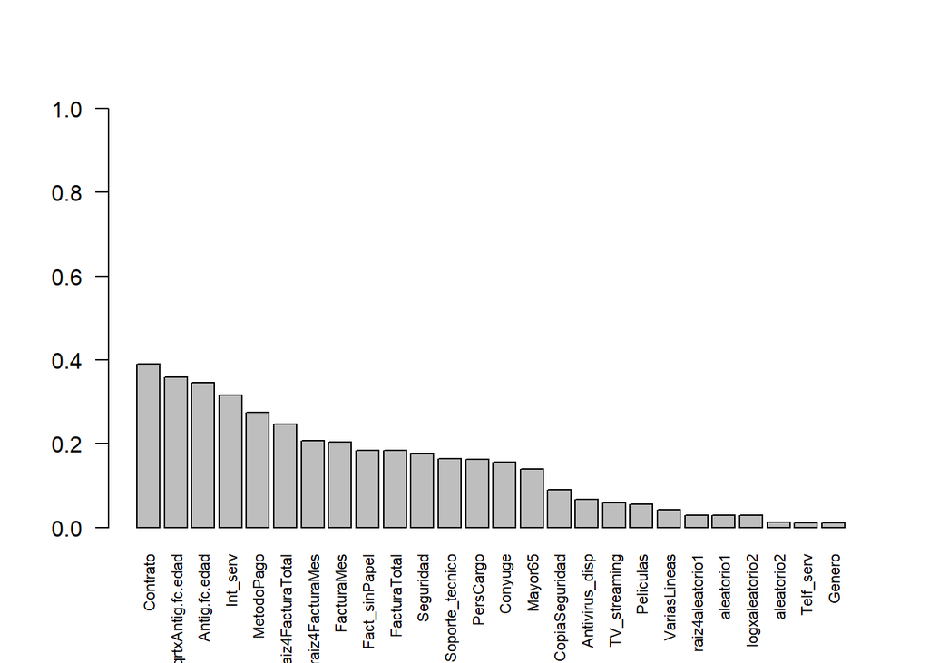

```r
# Evaluación sobre la importancia de las variables predictoras sobre la variable objetivo
graficoVcramer(input_obj, varObj)
```

Antes de comenzar con el desarrollo de modelos para predecir la fuga de clientes en la compañía telefónica, vamos a analizar la distribución de la variable objetivo. En este caso, existe una situación de desbalanceo hacia los 0 ya que la frecuencia es del 73,5%, esto es, el modelo tendrá mayor dificultad en reconocer los 1 por lo que si obtenemos un accuracy de 0,735 tenemos que sospechar y mirar detenidamente la sensibilidad y especificidad.

```r
# Cargar los datos depurados
todo <- todo_obj

# Comprobar la distribución de la variable objetivo
freq(todo$varObj)
```

```
##      n    % val%
## 0 4667 73.5 73.5
## 1 1686 26.5 26.5
```

## Partición training-test.

Se realiza la partición del archivo seleccionando las variables originales y la variable objetivo.

```r
# Posiciones de las variables
names(todo)
```

```
##  [1] "Genero"             "Mayor65"            "Conyuge"
##  [4] "PersCargo"          "Antig.fc.edad"      "Telf_serv"
##  [7] "VariasLineas"       "Int_serv"           "Seguridad"
## [10] "CopiaSeguridad"     "Antivirus_disp"     "Soporte_tecnico"
## [13] "TV_streaming"       "Peliculas"          "Contrato"
## [16] "Fact_sinPapel"      "MetodoPago"         "FacturaMes"
## [19] "FacturaTotal"       "aleatorio1"         "aleatorio2"
## [22] "sqrtxAntig.fc.edad" "raiz4FacturaMes"    "raiz4FacturaTotal"
## [25] "raiz4aleatorio1"    "logxaleatorio2"     "varObj"
```

```r
# Se realiza la partición
set.seed(1234567000)

trainIndex <- createDataPartition(todo$varObj, p = 0.8, list = FALSE)

data_train <- todo[trainIndex,]
data_test <- todo[-trainIndex,]
```

## Modelo completo de referencia.

En este primer modelo, salta a la vista que hay algunos efectos no significativos.

```r
# Primer modelo sin las variables transformadas
modeloInicial <- glm(varObj~., data = data_train[ ,c(1:21, 27)], family = binomial)
summary(modeloInicial)
```

```
##
## Call:
## glm(formula = varObj ~ ., family = binomial, data = data_train[,
##     c(1:21, 27)])
##
## Deviance Residuals:
##     Min       1Q   Median       3Q      Max
## -1.9206  -0.6711  -0.2960   0.7115   3.2565
##
## Coefficients:
##                                     Estimate Std. Error z value Pr(>|z|)
## (Intercept)                       -2.073e-01  2.501e-01  -0.829 0.407190
## GeneroMale                         2.974e-02  7.655e-02   0.389 0.697645
## Mayor651                           1.445e-01  1.021e-01   1.415 0.157090
## Conyuge1                          -7.324e-02  9.116e-02  -0.803 0.421762
## PersCargo1                        -1.929e-01  1.052e-01  -1.833 0.066860 .
## Antig.fc.edad                     -3.059e-02  4.697e-03  -6.512 7.44e-11 ***
## Telf_serv1                        -5.372e-01  1.748e-01  -3.072 0.002125 **
## VariasLineas1                      1.580e-01  9.660e-02   1.636 0.101840
## Int_servFiber optic                9.169e-01  1.465e-01   6.257 3.93e-10 ***
## Int_servNo                        -8.116e-01  1.907e-01  -4.256 2.08e-05 ***
## Seguridad1                        -4.136e-01  1.034e-01  -3.998 6.39e-05 ***
## CopiaSeguridad1                   -1.658e-01  9.452e-02  -1.754 0.079347 .
## Antivirus_disp1                   -6.606e-02  9.635e-02  -0.686 0.492908
## Soporte_tecnico1                  -3.382e-01  1.027e-01  -3.294 0.000989 ***
## TV_streaming1                      2.585e-01  1.056e-01   2.448 0.014355 *
## Peliculas1                         2.290e-01  1.043e-01   2.196 0.028114 *
## ContratoOne year                  -7.578e-01  1.247e-01  -6.075 1.24e-09 ***
## ContratoTwo year                  -1.625e+00  2.162e-01  -7.518 5.57e-14 ***
## Fact_sinPapel1                     3.913e-01  8.705e-02   4.495 6.95e-06 ***
## MetodoPagoCredit card (automatic) -7.508e-02  1.401e-01  -0.536 0.591978
## MetodoPagoElectronic check         3.797e-01  1.124e-01   3.379 0.000727 ***
## MetodoPagoMailed check             1.262e-01  1.363e-01   0.926 0.354517
## FacturaMes                         2.013e-03  4.698e-03   0.428 0.668320
## FacturaTotal                      -5.543e-06  5.609e-05  -0.099 0.921280
## aleatorio1                        -9.369e-02  1.316e-01  -0.712 0.476378
## aleatorio2                        -1.409e-01  1.310e-01  -1.075 0.282257
## ---
## Signif. codes:  0 '***' 0.001 '**' 0.01 '*' 0.05 '.' 0.1 ' ' 1
##
## (Dispersion parameter for binomial family taken to be 1)
##
##     Null deviance: 5882.3  on 5082  degrees of freedom
## Residual deviance: 4233.0  on 5057  degrees of freedom
## AIC: 4285
##
## Number of Fisher Scoring iterations: 6
```

Se consultan los valores del pseudo R2 en los conjuntos de training y test.

```r
# Consulta de los valores de pseudo R2
pseudoR2(modeloInicial, data_train, "varObj")
```

```
## [1] 0.2803843
```

```r
pseudoR2(modeloInicial, data_test, "varObj")
```

```
## [1] 0.2837391
```

```r
# Número de parámetros
modeloInicial$rank
```

```
## [1] 26
```

```r
# Factor de inflación de la varianza no estabilizado
car::vif(modeloInicial)
```

```
##                      GVIF Df GVIF^(1/(2*Df))
## Genero           1.008237  1        1.004110
## Mayor65          1.126932  1        1.061571
## Conyuge          1.364537  1        1.168134
## PersCargo        1.286540  1        1.134257
## Antig.fc.edad    6.007381  1        2.450996
## Telf_serv        1.935885  1        1.391361
## VariasLineas     1.570538  1        1.253211
## Int_serv         6.610203  2        1.603444
## Seguridad        1.186739  1        1.089375
## CopiaSeguridad   1.320716  1        1.149224
## Antivirus_disp   1.370119  1        1.170521
## Soporte_tecnico  1.222033  1        1.105456
## TV_streaming     1.839655  1        1.356339
## Peliculas        1.810349  1        1.345492
## Contrato         1.394101  2        1.086610
## Fact_sinPapel    1.106376  1        1.051844
## MetodoPago       1.299139  3        1.044582
## FacturaMes      10.313770  1        3.211506
## FacturaTotal     8.636182  1        2.938738
## aleatorio1       1.006514  1        1.003251
## aleatorio2       1.006780  1        1.003384
```

Es llamativo que una variable que habíamos visto que resultaba ser influyente a la respuesta, algunas de sus categorías no tengan estrellas en el modelo inicial desarrollado.

```r
table(todo$MetodoPago, todo$varObj)
```

```
##
##                                0    1
##   Bank transfer (automatic) 1063  220
##   Credit card (automatic)   1104  186
##   Electronic check          1423 1021
##   Mailed check              1077  259
```

```r
table(data_train$MetodoPago, data_train$varObj)
```

```
##
##                                0    1
##   Bank transfer (automatic)  865  168
##   Credit card (automatic)    858  149
##   Electronic check          1145  817
##   Mailed check               866  215
```

En efecto, el evento de fuga del cliente de la compañía telefónica con métodos de pago automáticos es relativamente muy inferior al evento de no fuga para estos mismos métodos de pago. Tal vez resulte interesante unificar estas categorías de modo que exista una sola categoría que representen los pagos automáticos sin hacer distinción entre si se ha realizado mediante transferencia bancaria o mediante tarjeta de crédito.

```r
names(todo)
```

```
##  [1] "Genero"             "Mayor65"            "Conyuge"
##  [4] "PersCargo"          "Antig.fc.edad"      "Telf_serv"
##  [7] "VariasLineas"       "Int_serv"           "Seguridad"
## [10] "CopiaSeguridad"     "Antivirus_disp"     "Soporte_tecnico"
## [13] "TV_streaming"       "Peliculas"          "Contrato"
## [16] "Fact_sinPapel"      "MetodoPago"         "FacturaMes"
## [19] "FacturaTotal"       "aleatorio1"         "aleatorio2"
## [22] "sqrtxAntig.fc.edad" "raiz4FacturaMes"    "raiz4FacturaTotal"
## [25] "raiz4aleatorio1"    "logxaleatorio2"     "varObj"
```

```r
# Uno categorías
todo$MetodoPago <- car::recode(todo$MetodoPago, "c('Bank transfer (automatic)', 'Credit card (automatic)')
                               = 'Automatic Payments'; c('Electronic check', 'Mailed check') = 'Not Automatic Payments'")
todo_obj$MetodoPago <- car::recode(todo_obj$MetodoPago, "c('Bank transfer (automatic)', 'Credit card (automatic)')
                               = 'Automatic Payments'; c('Electronic check', 'Mailed check') = 'Not Automatic Payments'")

# Actualizar la partición
data_train <- todo[trainIndex,]
data_test <- todo[-trainIndex,]

# Volver a ajustar el modelo inicial
modeloInicial <- glm(varObj~., data = data_train[ ,c(1:21, 27)], family=binomial)
summary(modeloInicial)
```

```
##
## Call:
## glm(formula = varObj ~ ., family = binomial, data = data_train[,
##     c(1:21, 27)])
##
## Deviance Residuals:
##     Min       1Q   Median       3Q      Max
## -1.9141  -0.6699  -0.2959   0.7211   3.2597
##
## Coefficients:
##                                    Estimate Std. Error z value Pr(>|z|)
## (Intercept)                      -2.985e-01  2.374e-01  -1.257 0.208760
## GeneroMale                        2.740e-02  7.646e-02   0.358 0.720035
## Mayor651                          1.571e-01  1.019e-01   1.541 0.123306
## Conyuge1                         -6.485e-02  9.101e-02  -0.713 0.476111
## PersCargo1                       -2.034e-01  1.050e-01  -1.937 0.052783 .
## Antig.fc.edad                    -3.011e-02  4.695e-03  -6.414 1.41e-10 ***
## Telf_serv1                       -5.548e-01  1.742e-01  -3.185 0.001447 **
## VariasLineas1                     1.629e-01  9.650e-02   1.688 0.091353 .
## Int_servFiber optic               9.358e-01  1.460e-01   6.411 1.45e-10 ***
## Int_servNo                       -8.507e-01  1.897e-01  -4.485 7.27e-06 ***
## Seguridad1                       -4.254e-01  1.032e-01  -4.123 3.74e-05 ***
## CopiaSeguridad1                  -1.660e-01  9.443e-02  -1.758 0.078705 .
## Antivirus_disp1                  -7.344e-02  9.614e-02  -0.764 0.444960
## Soporte_tecnico1                 -3.541e-01  1.024e-01  -3.458 0.000544 ***
## TV_streaming1                     2.630e-01  1.054e-01   2.495 0.012607 *
## Peliculas1                        2.398e-01  1.041e-01   2.304 0.021211 *
## ContratoOne year                 -7.618e-01  1.247e-01  -6.109 1.00e-09 ***
## ContratoTwo year                 -1.632e+00  2.160e-01  -7.556 4.16e-14 ***
## Fact_sinPapel1                    4.112e-01  8.658e-02   4.750 2.04e-06 ***
## MetodoPagoNot Automatic Payments  3.478e-01  8.637e-02   4.027 5.65e-05 ***
## FacturaMes                        2.694e-03  4.675e-03   0.576 0.564510
## FacturaTotal                     -9.976e-06  5.605e-05  -0.178 0.858743
## aleatorio1                       -1.008e-01  1.313e-01  -0.768 0.442583
## aleatorio2                       -1.429e-01  1.309e-01  -1.092 0.274988
## ---
## Signif. codes:  0 '***' 0.001 '**' 0.01 '*' 0.05 '.' 0.1 ' ' 1
##
## (Dispersion parameter for binomial family taken to be 1)
##
##     Null deviance: 5882.3  on 5082  degrees of freedom
## Residual deviance: 4238.5  on 5059  degrees of freedom
## AIC: 4286.5
##
## Number of Fisher Scoring iterations: 6
```

```r
# Consulta de los valores de pseudo R2
pseudoR2(modeloInicial, data_train, "varObj")
```

```
## [1] 0.2794545
```

```r
pseudoR2(modeloInicial, data_test, "varObj")
```

```
## [1] 0.2803162
```

```r
# Número de parámetros
modeloInicial$rank
```

```
## [1] 24
```

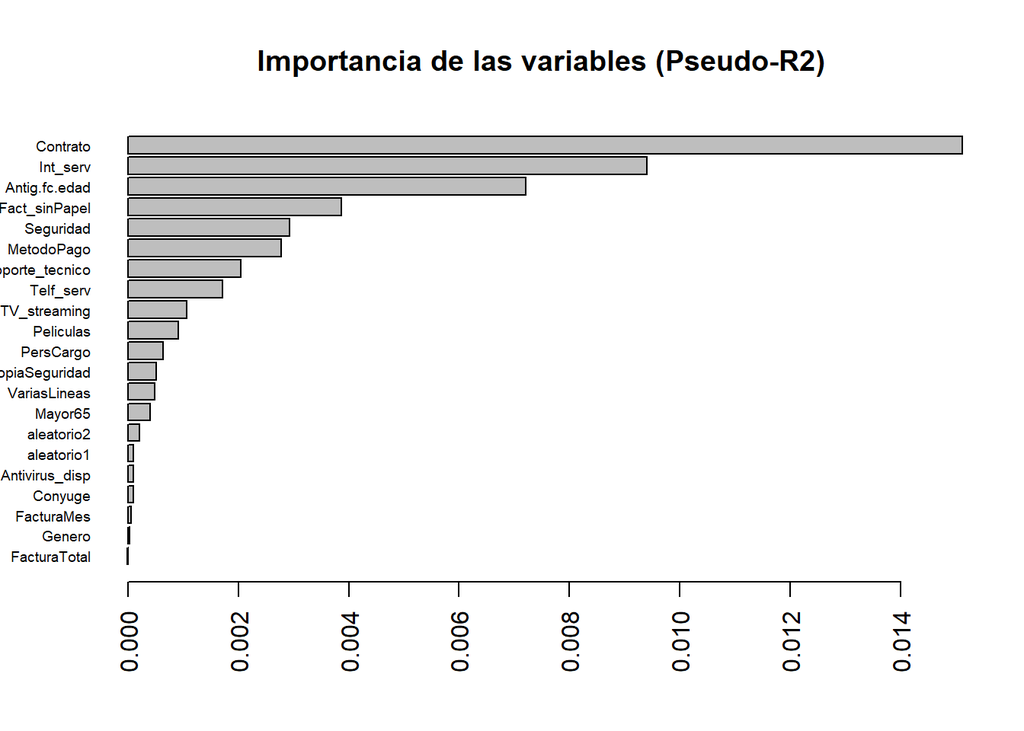

```r
# Importancia de las variables al pseudo R2
impVariablesLog(modeloInicial, "varObj")
```

Se prueba un segundo modelo con las variables más relevantes en cuanto a su aportación al pseudo R2, de manera que se eliminan todas las variables cuya aportación esté por debajo de las variables aleatorias de control creadas.

```r
# Segundo modelo
modelo2 <- update(modeloInicial,.~.-FacturaTotal-aleatorio2-Genero-FacturaMes-Conyuge-Antivirus_disp-aleatorio1)
summary(modelo2)
```

```
##
## Call:
## glm(formula = varObj ~ Mayor65 + PersCargo + Antig.fc.edad +
##     Telf_serv + VariasLineas + Int_serv + Seguridad + CopiaSeguridad +
##     Soporte_tecnico + TV_streaming + Peliculas + Contrato + Fact_sinPapel +
##     MetodoPago, family = binomial, data = data_train[, c(1:21,
##     27)])
##
## Deviance Residuals:
##     Min       1Q   Median       3Q      Max
## -1.9160  -0.6685  -0.2955   0.7269   3.2493
##
## Coefficients:
##                                   Estimate Std. Error z value Pr(>|z|)
## (Intercept)                      -0.331707   0.160747  -2.064 0.039062 *
## Mayor651                          0.143577   0.100818   1.424 0.154411
## PersCargo1                       -0.236688   0.095049  -2.490 0.012769 *
## Antig.fc.edad                    -0.031411   0.002569 -12.229  < 2e-16 ***
## Telf_serv1                       -0.506325   0.148491  -3.410 0.000650 ***
## VariasLineas1                     0.175170   0.091182   1.921 0.054718 .
## Int_servFiber optic               0.982493   0.105269   9.333  < 2e-16 ***
## Int_servNo                       -0.902637   0.157996  -5.713 1.11e-08 ***
## Seguridad1                       -0.415002   0.100120  -4.145 3.40e-05 ***
## CopiaSeguridad1                  -0.160795   0.089438  -1.798 0.072202 .
## Soporte_tecnico1                 -0.350556   0.099508  -3.523 0.000427 ***
## TV_streaming1                     0.276344   0.092404   2.991 0.002784 **
## Peliculas1                        0.251999   0.091853   2.744 0.006079 **
## ContratoOne year                 -0.773881   0.124014  -6.240 4.37e-10 ***
## ContratoTwo year                 -1.646618   0.214738  -7.668 1.75e-14 ***
## Fact_sinPapel1                    0.415107   0.086492   4.799 1.59e-06 ***
## MetodoPagoNot Automatic Payments  0.349268   0.086209   4.051 5.09e-05 ***
## ---
## Signif. codes:  0 '***' 0.001 '**' 0.01 '*' 0.05 '.' 0.1 ' ' 1
##
## (Dispersion parameter for binomial family taken to be 1)
##
##     Null deviance: 5882.3  on 5082  degrees of freedom
## Residual deviance: 4241.6  on 5066  degrees of freedom
## AIC: 4275.6
##
## Number of Fisher Scoring iterations: 6
```

Se consultan los valores del pseudo R2 en los conjuntos de training y test.

```r
# Consulta de los valores de pseudo R2
pseudoR2(modelo2, data_train, "varObj")
```

```
## [1] 0.2789151
```

```r
pseudoR2(modelo2, data_test, "varObj")
```

```
## [1] 0.2795158
```

```r
# Número de parámetros
modelo2$rank
```

```
## [1] 17
```

```r
# Factor de inflación de la varianza no estabilizado
car::vif(modelo2)
```

```
##                     GVIF Df GVIF^(1/(2*Df))
## Mayor65         1.101657  1        1.049598
## PersCargo       1.050802  1        1.025086
## Antig.fc.edad   1.801193  1        1.342085
## Telf_serv       1.397779  1        1.182277
## VariasLineas    1.404391  1        1.185070
## Int_serv        2.008197  2        1.190424
## Seguridad       1.114849  1        1.055864
## CopiaSeguridad  1.186161  1        1.089110
## Soporte_tecnico 1.149300  1        1.072054
## TV_streaming    1.414285  1        1.189237
## Peliculas       1.408845  1        1.186948
## Contrato        1.364865  2        1.080867
## Fact_sinPapel   1.094619  1        1.046240
## MetodoPago      1.070566  1        1.034682
```

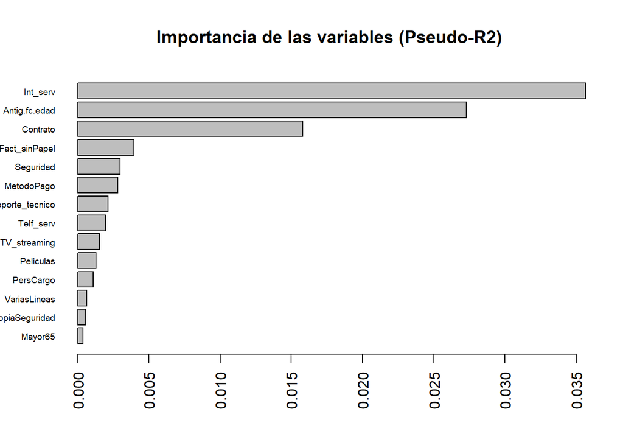

```r
# Importancia de las variables al pseudo R2
impVariablesLog(modelo2,'varObj')
```

```r
# Tercer modelo
modelo3 <- update(modelo2,.~.-Mayor65)
summary(modelo3)
```

```
##
## Call:
## glm(formula = varObj ~ PersCargo + Antig.fc.edad + Telf_serv +
##     VariasLineas + Int_serv + Seguridad + CopiaSeguridad + Soporte_tecnico +
##     TV_streaming + Peliculas + Contrato + Fact_sinPapel + MetodoPago,
##     family = binomial, data = data_train[, c(1:21, 27)])
##
## Deviance Residuals:
##     Min       1Q   Median       3Q      Max
## -1.8710  -0.6695  -0.2945   0.7295   3.2501
##
## Coefficients:
##                                   Estimate Std. Error z value Pr(>|z|)
## (Intercept)                      -0.311481   0.160036  -1.946 0.051616 .
## PersCargo1                       -0.257032   0.094004  -2.734 0.006252 **
## Antig.fc.edad                    -0.031100   0.002557 -12.162  < 2e-16 ***
## Telf_serv1                       -0.515523   0.148308  -3.476 0.000509 ***
## VariasLineas1                     0.180244   0.091054   1.980 0.047757 *
## Int_servFiber optic               0.998037   0.104721   9.530  < 2e-16 ***
## Int_servNo                       -0.911444   0.157869  -5.773 7.77e-09 ***
## Seguridad1                       -0.417904   0.100118  -4.174 2.99e-05 ***
## CopiaSeguridad1                  -0.158980   0.089396  -1.778 0.075341 .
## Soporte_tecnico1                 -0.361889   0.099180  -3.649 0.000263 ***
## TV_streaming1                     0.276550   0.092400   2.993 0.002763 **
## Peliculas1                        0.251577   0.091857   2.739 0.006166 **
## ContratoOne year                 -0.781091   0.123910  -6.304 2.91e-10 ***
## ContratoTwo year                 -1.657723   0.214562  -7.726 1.11e-14 ***
## Fact_sinPapel1                    0.421969   0.086346   4.887 1.02e-06 ***
## MetodoPagoNot Automatic Payments  0.351451   0.086179   4.078 4.54e-05 ***
## ---
## Signif. codes:  0 '***' 0.001 '**' 0.01 '*' 0.05 '.' 0.1 ' ' 1
##
## (Dispersion parameter for binomial family taken to be 1)
##
##     Null deviance: 5882.3  on 5082  degrees of freedom
## Residual deviance: 4243.7  on 5067  degrees of freedom
## AIC: 4275.7
##
## Number of Fisher Scoring iterations: 6
```

```r
# Consulta de los valores de pseudo R2
pseudoR2(modelo3, data_train, "varObj")
```

```
## [1] 0.278571
```

```r
pseudoR2(modelo3, data_test, "varObj")
```

```
## [1] 0.2772686
```

```r
# Número de parámetros
modelo3$rank
```

```
## [1] 16
```

```r
# Factor de inflación de la varianza no estabilizado
car::vif(modelo3)
```

```
##                     GVIF Df GVIF^(1/(2*Df))
## PersCargo       1.026703  1        1.013264
## Antig.fc.edad   1.787293  1        1.336897
## Telf_serv       1.395831  1        1.181453
## VariasLineas    1.401752  1        1.183956
## Int_serv        1.970757  2        1.184836
## Seguridad       1.114487  1        1.055693
## CopiaSeguridad  1.185672  1        1.088885
## Soporte_tecnico 1.141329  1        1.068330
## TV_streaming    1.415171  1        1.189610
## Peliculas       1.410026  1        1.187445
## Contrato        1.361203  2        1.080142
## Fact_sinPapel   1.090891  1        1.044457
## MetodoPago      1.070284  1        1.034545
```

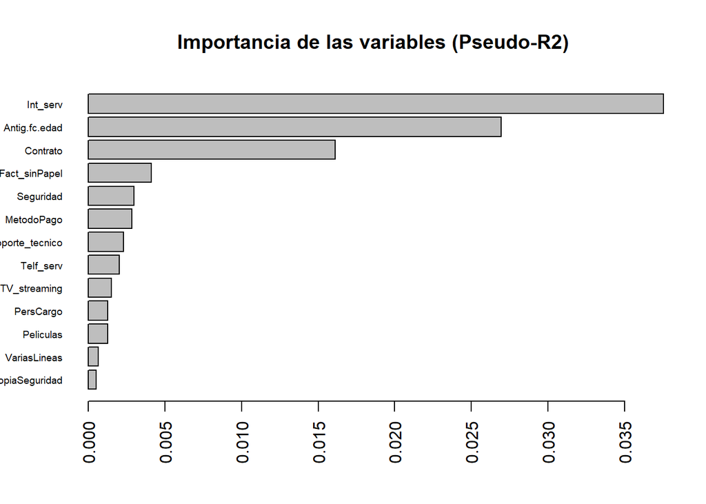

```r
# Importancia de las variables al pseudo R2
impVariablesLog(modelo3,'varObj')
```

```r
# Cuarto modelo
modelo4 <- update(modelo3,.~.-CopiaSeguridad)
summary(modelo4)
```

```
##
## Call:
## glm(formula = varObj ~ PersCargo + Antig.fc.edad + Telf_serv +
##     VariasLineas + Int_serv + Seguridad + Soporte_tecnico + TV_streaming +
##     Peliculas + Contrato + Fact_sinPapel + MetodoPago, family = binomial,
##     data = data_train[, c(1:21, 27)])
##
## Deviance Residuals:
##     Min       1Q   Median       3Q      Max
## -1.8545  -0.6693  -0.2945   0.7355   3.2800
##
## Coefficients:
##                                   Estimate Std. Error z value Pr(>|z|)
## (Intercept)                      -0.335447   0.159457  -2.104 0.035406 *
## PersCargo1                       -0.260820   0.093935  -2.777 0.005493 **
## Antig.fc.edad                    -0.032100   0.002497 -12.857  < 2e-16 ***
## Telf_serv1                       -0.509955   0.148252  -3.440 0.000582 ***
## VariasLineas1                     0.171823   0.090869   1.891 0.058641 .
## Int_servFiber optic               0.997716   0.104671   9.532  < 2e-16 ***
## Int_servNo                       -0.875522   0.156637  -5.590 2.28e-08 ***
## Seguridad1                       -0.423645   0.099968  -4.238 2.26e-05 ***
## Soporte_tecnico1                 -0.366026   0.099068  -3.695 0.000220 ***
## TV_streaming1                     0.272294   0.092303   2.950 0.003178 **
## Peliculas1                        0.252105   0.091778   2.747 0.006016 **
## ContratoOne year                 -0.787741   0.123819  -6.362 1.99e-10 ***
## ContratoTwo year                 -1.664388   0.214492  -7.760 8.52e-15 ***
## Fact_sinPapel1                    0.417446   0.086289   4.838 1.31e-06 ***
## MetodoPagoNot Automatic Payments  0.352509   0.086138   4.092 4.27e-05 ***
## ---
## Signif. codes:  0 '***' 0.001 '**' 0.01 '*' 0.05 '.' 0.1 ' ' 1
##
## (Dispersion parameter for binomial family taken to be 1)
##
##     Null deviance: 5882.3  on 5082  degrees of freedom
## Residual deviance: 4246.8  on 5068  degrees of freedom
## AIC: 4276.8
##
## Number of Fisher Scoring iterations: 6
```

```r
# Consulta de los valores de pseudo R2
pseudoR2(modelo4, data_train, "varObj")
```

```
## [1] 0.2780335
```

```r
pseudoR2(modelo4, data_test, "varObj")
```

```
## [1] 0.275723
```

```r
# Número de parámetros
modelo4$rank
```

```
## [1] 15
```

```r
# Factor de inflación de la varianza estabilizado
car::vif(modelo4)
```

```
##                     GVIF Df GVIF^(1/(2*Df))
## PersCargo       1.026068  1        1.012950
## Antig.fc.edad   1.708433  1        1.307070
## Telf_serv       1.394482  1        1.180882
## VariasLineas    1.397999  1        1.182370
## Int_serv        1.930917  2        1.178802
## Seguridad       1.113350  1        1.055154
## Soporte_tecnico 1.141089  1        1.068217
## TV_streaming    1.414305  1        1.189246
## Peliculas       1.409243  1        1.187115
## Contrato        1.357891  2        1.079484
## Fact_sinPapel   1.090325  1        1.044186
## MetodoPago      1.070449  1        1.034625
```

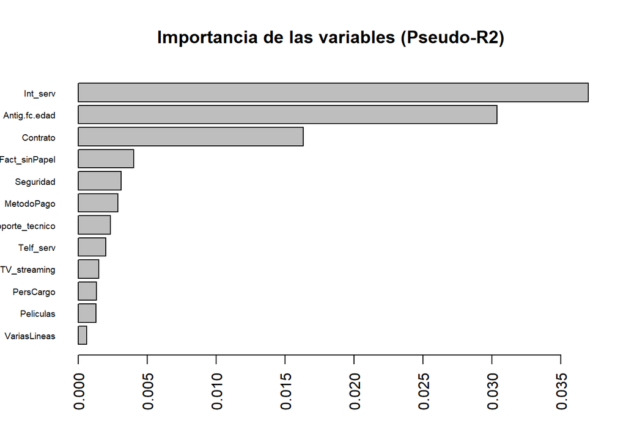

```r
# Importancia de las variables al pseudo R2
impVariablesLog(modelo4,'varObj')
```

```r
# Quinto modelo
modelo5 <- update(modelo4,.~.-VariasLineas)
summary(modelo5)
```

```
##
## Call:
## glm(formula = varObj ~ PersCargo + Antig.fc.edad + Telf_serv +
##     Int_serv + Seguridad + Soporte_tecnico + TV_streaming + Peliculas +
##     Contrato + Fact_sinPapel + MetodoPago, family = binomial,
##     data = data_train[, c(1:21, 27)])
##
## Deviance Residuals:
##     Min       1Q   Median       3Q      Max
## -1.8241  -0.6680  -0.2919   0.7299   3.3026
##
## Coefficients:
##                                   Estimate Std. Error z value Pr(>|z|)
## (Intercept)                      -0.366599   0.158534  -2.312 0.020754 *
## PersCargo1                       -0.267336   0.093891  -2.847 0.004409 **
## Antig.fc.edad                    -0.030919   0.002412 -12.820  < 2e-16 ***
## Telf_serv1                       -0.452253   0.144849  -3.122 0.001795 **
## Int_servFiber optic               1.030030   0.103392   9.962  < 2e-16 ***
## Int_servNo                       -0.896293   0.156213  -5.738 9.60e-09 ***
## Seguridad1                       -0.424596   0.099926  -4.249 2.15e-05 ***
## Soporte_tecnico1                 -0.371328   0.099040  -3.749 0.000177 ***
## TV_streaming1                     0.281638   0.092142   3.057 0.002239 **
## Peliculas1                        0.260545   0.091628   2.844 0.004462 **
## ContratoOne year                 -0.802761   0.123580  -6.496 8.25e-11 ***
## ContratoTwo year                 -1.670355   0.214489  -7.788 6.83e-15 ***
## Fact_sinPapel1                    0.427633   0.086143   4.964 6.90e-07 ***
## MetodoPagoNot Automatic Payments  0.349307   0.086082   4.058 4.95e-05 ***
## ---
## Signif. codes:  0 '***' 0.001 '**' 0.01 '*' 0.05 '.' 0.1 ' ' 1
##
## (Dispersion parameter for binomial family taken to be 1)
##
##     Null deviance: 5882.3  on 5082  degrees of freedom
## Residual deviance: 4250.4  on 5069  degrees of freedom
## AIC: 4278.4
##
## Number of Fisher Scoring iterations: 6
```

```r
# Consulta de los valores de pseudo R2
pseudoR2(modelo5, data_train, "varObj")
```

```
## [1] 0.2774253
```

```r
pseudoR2(modelo5, data_test, "varObj")
```

```
## [1] 0.2713552
```

```r
# Número de parámetros
modelo5$rank
```

```
## [1] 14
```

```r
# Factor de inflación de la varianza estabilizado
car::vif(modelo5)
```

```
##                     GVIF Df GVIF^(1/(2*Df))
## PersCargo       1.024739  1        1.012294
## Antig.fc.edad   1.595689  1        1.263206
## Telf_serv       1.335302  1        1.155553
## Int_serv        1.841795  2        1.164958
## Seguridad       1.113341  1        1.055150
## Soporte_tecnico 1.139959  1        1.067688
## TV_streaming    1.411002  1        1.187856
## Peliculas       1.406346  1        1.185895
## Contrato        1.352468  2        1.078405
## Fact_sinPapel   1.086535  1        1.042370
## MetodoPago      1.070057  1        1.034436
```

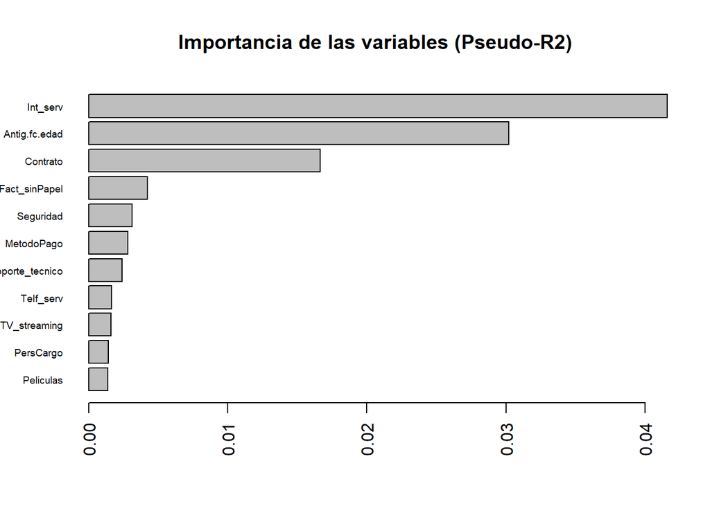

```r
# Importancia de las variables al pseudo R2
impVariablesLog(modelo5,'varObj')
```

```r
# Sexto modelo
modelo6 <- update(modelo5,.~.-Peliculas)
summary(modelo6)
```

```
##
## Call:
## glm(formula = varObj ~ PersCargo + Antig.fc.edad + Telf_serv +
##     Int_serv + Seguridad + Soporte_tecnico + TV_streaming + Contrato +
##     Fact_sinPapel + MetodoPago, family = binomial, data = data_train[,
##     c(1:21, 27)])
##
## Deviance Residuals:
##     Min       1Q   Median       3Q      Max
## -1.7941  -0.6705  -0.2944   0.7425   3.2662
##
## Coefficients:
##                                   Estimate Std. Error z value Pr(>|z|)
## (Intercept)                      -0.335651   0.157884  -2.126 0.033509 *
## PersCargo1                       -0.277346   0.093759  -2.958 0.003096 **
## Antig.fc.edad                    -0.029838   0.002375 -12.564  < 2e-16 ***
## Telf_serv1                       -0.465100   0.144593  -3.217 0.001297 **
## Int_servFiber optic               1.059253   0.102848  10.299  < 2e-16 ***
## Int_servNo                       -0.938791   0.155346  -6.043 1.51e-09 ***
## Seguridad1                       -0.427205   0.099823  -4.280 1.87e-05 ***
## Soporte_tecnico1                 -0.358424   0.098778  -3.629 0.000285 ***
## TV_streaming1                     0.364918   0.087320   4.179 2.93e-05 ***
## ContratoOne year                 -0.782425   0.123211  -6.350 2.15e-10 ***
## ContratoTwo year                 -1.654187   0.214366  -7.717 1.19e-14 ***
## Fact_sinPapel1                    0.436962   0.085986   5.082 3.74e-07 ***
## MetodoPagoNot Automatic Payments  0.355694   0.085971   4.137 3.51e-05 ***
## ---
## Signif. codes:  0 '***' 0.001 '**' 0.01 '*' 0.05 '.' 0.1 ' ' 1
##
## (Dispersion parameter for binomial family taken to be 1)
##
##     Null deviance: 5882.3  on 5082  degrees of freedom
## Residual deviance: 4258.5  on 5070  degrees of freedom
## AIC: 4284.5
##
## Number of Fisher Scoring iterations: 6
```

```r
# Consulta de los valores de pseudo R2
pseudoR2(modelo6, data_train, "varObj")
```

```
## [1] 0.276046
```

```r
pseudoR2(modelo6, data_test, "varObj")
```

```
## [1] 0.2694649
```

```r
# Número de parámetros
modelo6$rank
```

```
## [1] 13
```

```r
# Factor de inflación de la varianza no estabilizado
car::vif(modelo6)
```

```
##                     GVIF Df GVIF^(1/(2*Df))
## PersCargo       1.023119  1        1.011494
## Antig.fc.edad   1.550682  1        1.245264
## Telf_serv       1.334335  1        1.155134
## Int_serv        1.783856  2        1.155686
## Seguridad       1.112815  1        1.054901
## Soporte_tecnico 1.135900  1        1.065786
## TV_streaming    1.269956  1        1.126923
## Contrato        1.349023  2        1.077717
## Fact_sinPapel   1.084875  1        1.041573
## MetodoPago      1.068914  1        1.033883
```

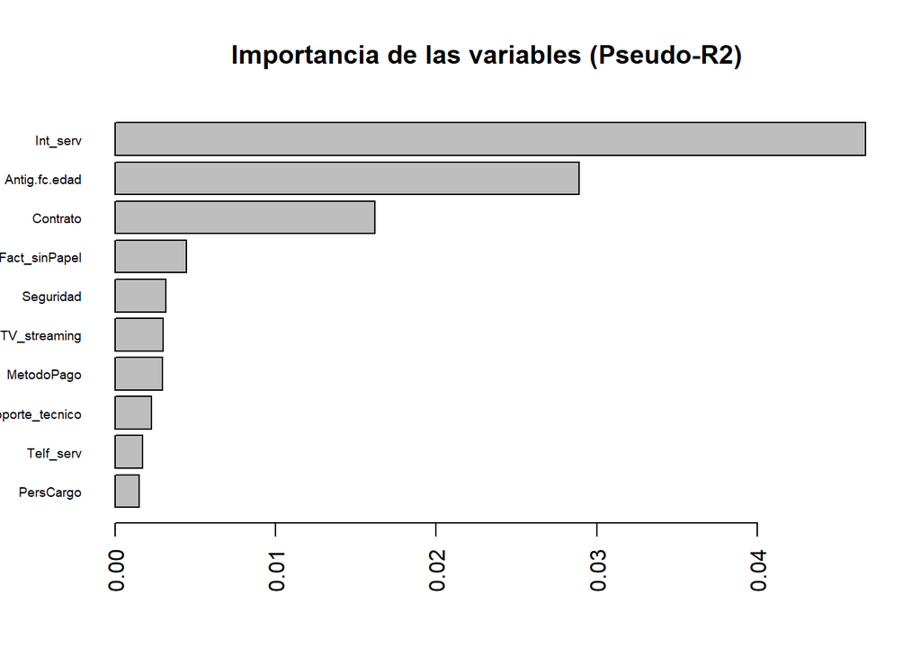

```r
# Importancia de las variables al pseudo R2
impVariablesLog(modelo6,'varObj')
```

```r
# Séptimo modelo
modelo7 <- update(modelo6,.~.-PersCargo)
summary(modelo7)
```

```
##
## Call:
## glm(formula = varObj ~ Antig.fc.edad + Telf_serv + Int_serv +
##     Seguridad + Soporte_tecnico + TV_streaming + Contrato + Fact_sinPapel +
##     MetodoPago, family = binomial, data = data_train[, c(1:21,
##     27)])
##
## Deviance Residuals:
##     Min       1Q   Median       3Q      Max
## -1.7799  -0.6676  -0.2943   0.7440   3.3105
##
## Coefficients:
##                                   Estimate Std. Error z value Pr(>|z|)
## (Intercept)                      -0.395270   0.156326  -2.528 0.011455 *
## Antig.fc.edad                    -0.030193   0.002368 -12.748  < 2e-16 ***
## Telf_serv1                       -0.475583   0.144228  -3.297 0.000976 ***
## Int_servFiber optic               1.079856   0.102531  10.532  < 2e-16 ***
## Int_servNo                       -0.948774   0.155153  -6.115 9.65e-10 ***
## Seguridad1                       -0.434841   0.099680  -4.362 1.29e-05 ***
## Soporte_tecnico1                 -0.366451   0.098591  -3.717 0.000202 ***
## TV_streaming1                     0.367127   0.087172   4.212 2.54e-05 ***
## ContratoOne year                 -0.802146   0.122846  -6.530 6.59e-11 ***
## ContratoTwo year                 -1.689778   0.213710  -7.907 2.64e-15 ***
## Fact_sinPapel1                    0.445839   0.085818   5.195 2.05e-07 ***
## MetodoPagoNot Automatic Payments  0.362592   0.085878   4.222 2.42e-05 ***
## ---
## Signif. codes:  0 '***' 0.001 '**' 0.01 '*' 0.05 '.' 0.1 ' ' 1
##
## (Dispersion parameter for binomial family taken to be 1)
##
##     Null deviance: 5882.3  on 5082  degrees of freedom
## Residual deviance: 4267.4  on 5071  degrees of freedom
## AIC: 4291.4
##
## Number of Fisher Scoring iterations: 6
```

```r
# Consulta de los valores de pseudo R2
pseudoR2(modelo7, data_train, "varObj")
```

```
## [1] 0.2745384
```

```r
pseudoR2(modelo7, data_test, "varObj")
```

```
## [1] 0.2702276
```

```r
# Número de parámetros
modelo7$rank
```

```
## [1] 12
```

```r
# Factor de inflación de la varianza no estabilizado
car::vif(modelo7)
```

```
##                     GVIF Df GVIF^(1/(2*Df))
## Antig.fc.edad   1.541802  1        1.241693
## Telf_serv       1.333671  1        1.154847
## Int_serv        1.774424  2        1.154156
## Seguridad       1.111986  1        1.054507
## Soporte_tecnico 1.133540  1        1.064678
## TV_streaming    1.267838  1        1.125983
## Contrato        1.338151  2        1.075539
## Fact_sinPapel   1.083585  1        1.040954
## MetodoPago      1.068253  1        1.033563
```

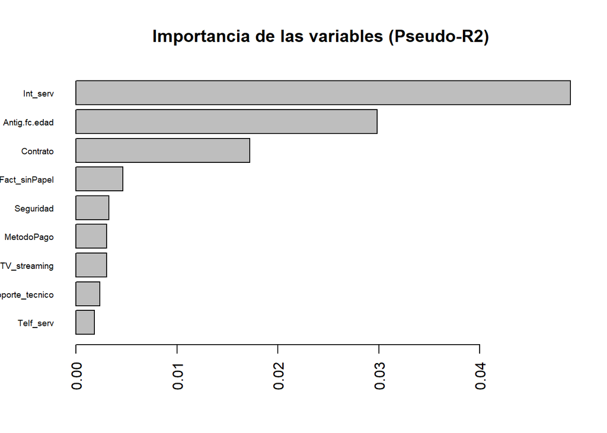

```r
# Importancia de las variables al pseudo R2
impVariablesLog(modelo7,'varObj')
```

```r
# Octavo modelo
modelo8 <- update(modelo7,.~.-Telf_serv)
summary(modelo8)
```

```
##
## Call:
## glm(formula = varObj ~ Antig.fc.edad + Int_serv + Seguridad +
##     Soporte_tecnico + TV_streaming + Contrato + Fact_sinPapel +
##     MetodoPago, family = binomial, data = data_train[, c(1:21,
##     27)])
##
## Deviance Residuals:
##     Min       1Q   Median       3Q      Max
## -1.7828  -0.6761  -0.2956   0.7410   3.2679
##
## Coefficients:
##                                   Estimate Std. Error z value Pr(>|z|)
## (Intercept)                      -0.727272   0.121305  -5.995 2.03e-09 ***
## Antig.fc.edad                    -0.029815   0.002365 -12.609  < 2e-16 ***
## Int_servFiber optic               0.925657   0.089755  10.313  < 2e-16 ***
## Int_servNo                       -1.101789   0.147104  -7.490 6.89e-14 ***
## Seguridad1                       -0.450373   0.099385  -4.532 5.85e-06 ***
## Soporte_tecnico1                 -0.376904   0.098371  -3.831 0.000127 ***
## TV_streaming1                     0.377356   0.087065   4.334 1.46e-05 ***
## ContratoOne year                 -0.809340   0.122766  -6.593 4.32e-11 ***
## ContratoTwo year                 -1.693244   0.213739  -7.922 2.34e-15 ***
## Fact_sinPapel1                    0.443725   0.085651   5.181 2.21e-07 ***
## MetodoPagoNot Automatic Payments  0.371212   0.085739   4.330 1.49e-05 ***
## ---
## Signif. codes:  0 '***' 0.001 '**' 0.01 '*' 0.05 '.' 0.1 ' ' 1
##
## (Dispersion parameter for binomial family taken to be 1)
##
##     Null deviance: 5882.3  on 5082  degrees of freedom
## Residual deviance: 4278.1  on 5072  degrees of freedom
## AIC: 4300.1
##
## Number of Fisher Scoring iterations: 6
```

```r
# Consulta de los valores de pseudo R2
pseudoR2(modelo8, data_train, "varObj")
```

```
## [1] 0.2727138
```

```r
pseudoR2(modelo8, data_test, "varObj")
```

```
## [1] 0.2707393
```

```r
# Número de parámetros
modelo8$rank
```

```
## [1] 11
```

```r
# Factor de inflación de la varianza no estabilizado
car::vif(modelo8)
```

```
##                     GVIF Df GVIF^(1/(2*Df))
## Antig.fc.edad   1.542402  1        1.241935
## Int_serv        1.344128  2        1.076738
## Seguridad       1.109295  1        1.053231
## Soporte_tecnico 1.133614  1        1.064713
## TV_streaming    1.267650  1        1.125900
## Contrato        1.339927  2        1.075896
## Fact_sinPapel   1.082655  1        1.040507
## MetodoPago      1.067282  1        1.033094
```

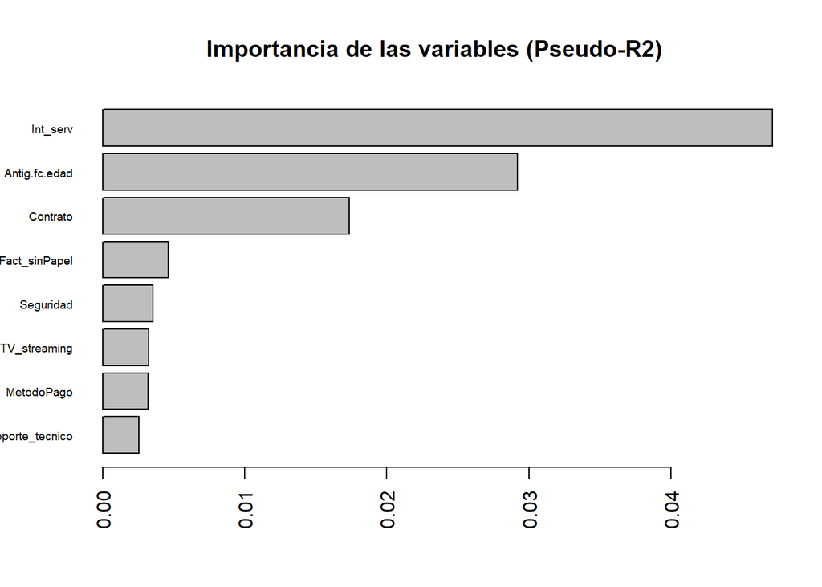

```r
# Importancia de las variables al pseudo R2
impVariablesLog(modelo8,'varObj')
```

```r
# Noveno modelo
modelo9 <- update(modelo8,.~.-Soporte_tecnico)
summary(modelo9)
```

```
##
## Call:
## glm(formula = varObj ~ Antig.fc.edad + Int_serv + Seguridad +
##     TV_streaming + Contrato + Fact_sinPapel + MetodoPago, family = binomial,
##     data = data_train[, c(1:21, 27)])
##
## Deviance Residuals:
##     Min       1Q   Median       3Q      Max
## -1.7576  -0.6729  -0.2955   0.7512   3.2371
##
## Coefficients:
##                                   Estimate Std. Error z value Pr(>|z|)
## (Intercept)                      -0.809657   0.119249  -6.790 1.12e-11 ***
## Antig.fc.edad                    -0.030620   0.002354 -13.009  < 2e-16 ***
## Int_servFiber optic               0.970601   0.088867  10.922  < 2e-16 ***
## Int_servNo                       -1.006927   0.145133  -6.938 3.98e-12 ***
## Seguridad1                       -0.485449   0.098782  -4.914 8.91e-07 ***
## TV_streaming1                     0.344648   0.086316   3.993 6.53e-05 ***
## ContratoOne year                 -0.852959   0.122068  -6.988 2.80e-12 ***
## ContratoTwo year                 -1.795607   0.212049  -8.468  < 2e-16 ***
## Fact_sinPapel1                    0.442459   0.085454   5.178 2.25e-07 ***
## MetodoPagoNot Automatic Payments  0.387200   0.085488   4.529 5.92e-06 ***
## ---
## Signif. codes:  0 '***' 0.001 '**' 0.01 '*' 0.05 '.' 0.1 ' ' 1
##
## (Dispersion parameter for binomial family taken to be 1)
##
##     Null deviance: 5882.3  on 5082  degrees of freedom
## Residual deviance: 4293.0  on 5073  degrees of freedom
## AIC: 4313
##
## Number of Fisher Scoring iterations: 6
```

```r
# Consulta de los valores de pseudo R2
pseudoR2(modelo9, data_train, "varObj")
```

```
## [1] 0.2701892
```

```r
pseudoR2(modelo9, data_test, "varObj")
```

```
## [1] 0.2662841
```

```r
# Número de parámetros
modelo9$rank
```

```
## [1] 10
```

```r
# Factor de inflación de la varianza no estabilizado
car::vif(modelo9)
```

```
##                   GVIF Df GVIF^(1/(2*Df))
## Antig.fc.edad 1.532171  1        1.237809
## Int_serv      1.299523  2        1.067692
## Seguridad     1.101054  1        1.049311
## TV_streaming  1.253510  1        1.119602
## Contrato      1.310813  2        1.070004
## Fact_sinPapel 1.082610  1        1.040486
## MetodoPago    1.065535  1        1.032248
```

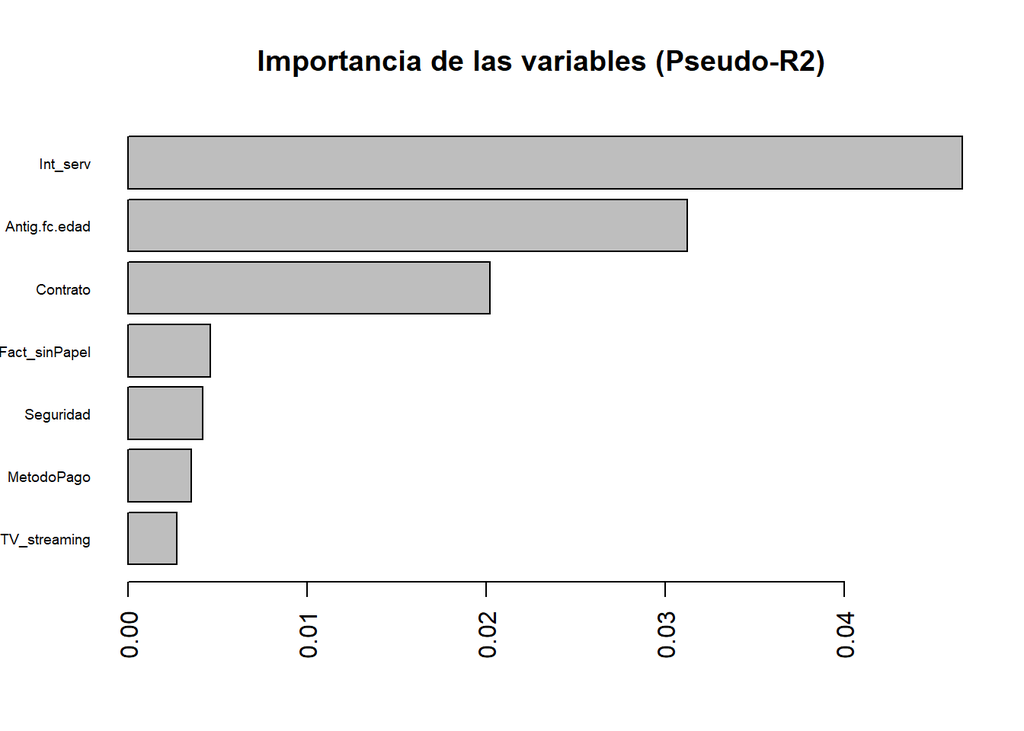

```r
# Importancia de las variables al pseudo R2
impVariablesLog(modelo9,'varObj')
```

```r
# Decimo modelo
modelo10 <- update(modelo9,.~.-TV_streaming)
summary(modelo10)
```

```
##
## Call:
## glm(formula = varObj ~ Antig.fc.edad + Int_serv + Seguridad +
##     Contrato + Fact_sinPapel + MetodoPago, family = binomial,
##     data = data_train[, c(1:21, 27)])
##
## Deviance Residuals:
##     Min       1Q   Median       3Q      Max
## -1.6597  -0.6860  -0.3002   0.7625   3.1897
##
## Coefficients:
##                                   Estimate Std. Error z value Pr(>|z|)
## (Intercept)                      -0.774774   0.118713  -6.526 6.74e-11 ***
## Antig.fc.edad                    -0.028644   0.002287 -12.527  < 2e-16 ***
## Int_servFiber optic               1.021337   0.088014  11.604  < 2e-16 ***
## Int_servNo                       -1.099413   0.142933  -7.692 1.45e-14 ***
## Seguridad1                       -0.495150   0.098540  -5.025 5.04e-07 ***
## ContratoOne year                 -0.803817   0.121088  -6.638 3.17e-11 ***
## ContratoTwo year                 -1.748507   0.211622  -8.262  < 2e-16 ***
## Fact_sinPapel1                    0.468734   0.084997   5.515 3.49e-08 ***
## MetodoPagoNot Automatic Payments  0.399891   0.085299   4.688 2.76e-06 ***
## ---
## Signif. codes:  0 '***' 0.001 '**' 0.01 '*' 0.05 '.' 0.1 ' ' 1
##
## (Dispersion parameter for binomial family taken to be 1)
##
##     Null deviance: 5882.3  on 5082  degrees of freedom
## Residual deviance: 4309.0  on 5074  degrees of freedom
## AIC: 4327
##
## Number of Fisher Scoring iterations: 6
```

```r
# Consulta de los valores de pseudo R2
pseudoR2(modelo10, data_train, "varObj")
```

```
## [1] 0.2674598
```

```r
pseudoR2(modelo10, data_test, "varObj")
```

```
## [1] 0.2602662
```

```r
# Número de parámetros
modelo10$rank
```

```
## [1] 9
```

```r
# Factor de inflación de la varianza no estabilizado
car::vif(modelo10)
```

```
##                   GVIF Df GVIF^(1/(2*Df))
## Antig.fc.edad 1.452907  1        1.205366
## Int_serv      1.215459  2        1.049990
## Seguridad     1.100809  1        1.049194
## Contrato      1.298008  2        1.067381
## Fact_sinPapel 1.075272  1        1.036953
## MetodoPago    1.063430  1        1.031227
```

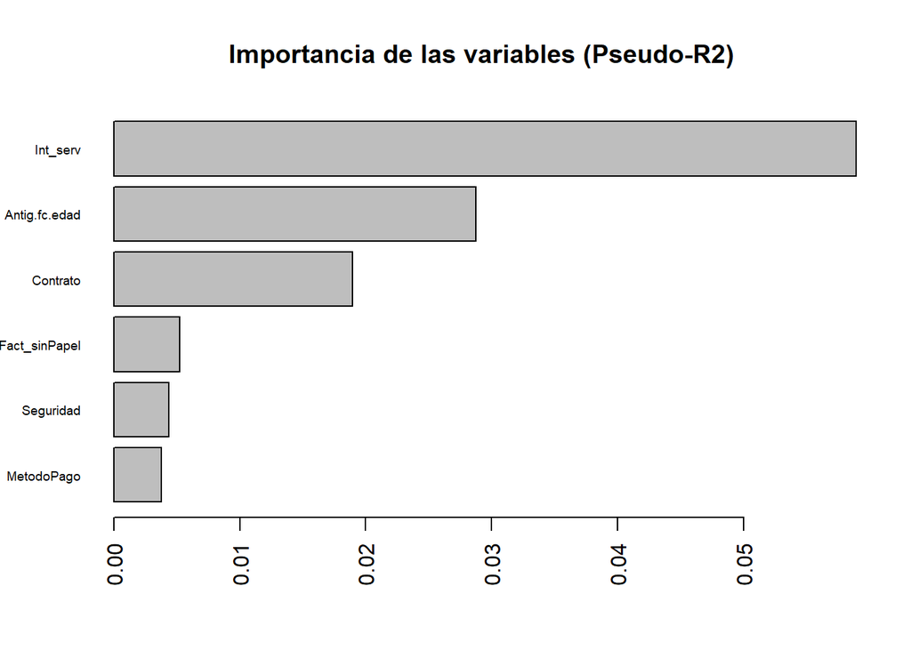

```r
# Importancia de las variables al pseudo R2
impVariablesLog(modelo10,'varObj')
```

```r
# Undecimo modelo
modelo11 <- update(modelo10,.~.-MetodoPago)
summary(modelo11)
```

```
##
## Call:
## glm(formula = varObj ~ Antig.fc.edad + Int_serv + Seguridad +
##     Contrato + Fact_sinPapel, family = binomial, data = data_train[,
##     c(1:21, 27)])
##
## Deviance Residuals:
##     Min       1Q   Median       3Q      Max
## -1.6313  -0.6907  -0.3086   0.7835   3.2063
##
## Coefficients:
##                      Estimate Std. Error z value Pr(>|z|)
## (Intercept)         -0.448199   0.095363  -4.700 2.60e-06 ***
## Antig.fc.edad       -0.030682   0.002244 -13.670  < 2e-16 ***
## Int_servFiber optic  1.034284   0.087710  11.792  < 2e-16 ***
## Int_servNo          -1.090645   0.142605  -7.648 2.04e-14 ***
## Seguridad1          -0.521024   0.098115  -5.310 1.09e-07 ***
## ContratoOne year    -0.832036   0.120625  -6.898 5.28e-12 ***
## ContratoTwo year    -1.785213   0.211238  -8.451  < 2e-16 ***
## Fact_sinPapel1       0.468304   0.084728   5.527 3.25e-08 ***
## ---
## Signif. codes:  0 '***' 0.001 '**' 0.01 '*' 0.05 '.' 0.1 ' ' 1
##
## (Dispersion parameter for binomial family taken to be 1)
##
##     Null deviance: 5882.3  on 5082  degrees of freedom
## Residual deviance: 4331.2  on 5075  degrees of freedom
## AIC: 4347.2
##
## Number of Fisher Scoring iterations: 6
```

```r
# Consulta de los valores de pseudo R2
pseudoR2(modelo11, data_train, "varObj")
```

```
## [1] 0.2636856
```

```r
pseudoR2(modelo11, data_test, "varObj")
```

```
## [1] 0.2597856
```

```r
# Número de parámetros
modelo11$rank
```

```
## [1] 8
```

```r
# Factor de inflación de la varianza estabilizado
car::vif(modelo11)
```

```
##                   GVIF Df GVIF^(1/(2*Df))
## Antig.fc.edad 1.404554  1        1.185139
## Int_serv      1.212547  2        1.049360
## Seguridad     1.096306  1        1.047046
## Contrato      1.290602  2        1.065855
## Fact_sinPapel 1.073044  1        1.035878
```

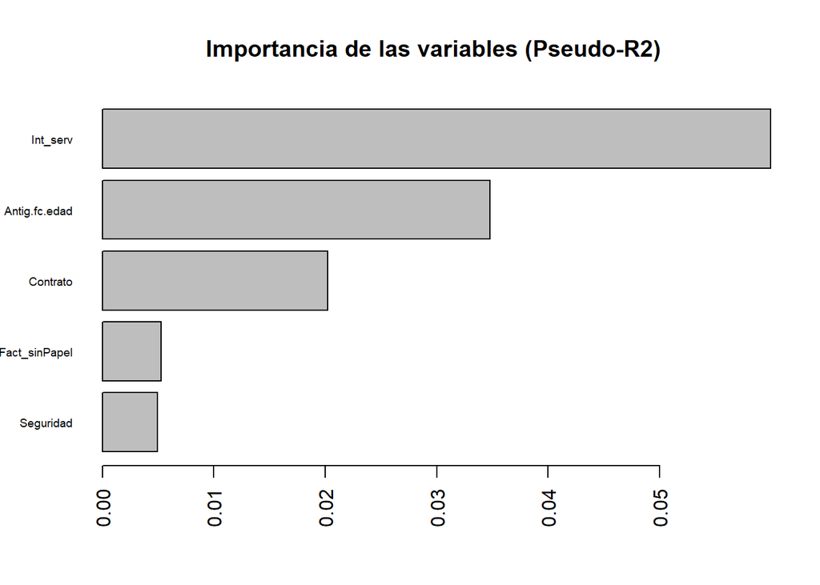

```r
# Importancia de las variables al pseudo R2
impVariablesLog(modelo11,'varObj')
```

```r
# Duodecimo modelo
modelo12 <- update(modelo11,.~.-Seguridad)
summary(modelo12)
```

```
##
## Call:
## glm(formula = varObj ~ Antig.fc.edad + Int_serv + Contrato +
##     Fact_sinPapel, family = binomial, data = data_train[, c(1:21,
##     27)])
##
## Deviance Residuals:
##     Min       1Q   Median       3Q      Max
## -1.6149  -0.7020  -0.3034   0.7959   3.2638
##
## Coefficients:
##                      Estimate Std. Error z value Pr(>|z|)
## (Intercept)         -0.577944   0.092129  -6.273 3.54e-10 ***
## Antig.fc.edad       -0.032784   0.002205 -14.866  < 2e-16 ***
## Int_servFiber optic  1.105523   0.086401  12.795  < 2e-16 ***
## Int_servNo          -0.930187   0.139846  -6.652 2.90e-11 ***
## ContratoOne year    -0.876922   0.119826  -7.318 2.51e-13 ***
## ContratoTwo year    -1.879022   0.210043  -8.946  < 2e-16 ***
## Fact_sinPapel1       0.492421   0.084208   5.848 4.99e-09 ***
## ---
## Signif. codes:  0 '***' 0.001 '**' 0.01 '*' 0.05 '.' 0.1 ' ' 1
##
## (Dispersion parameter for binomial family taken to be 1)
##
##     Null deviance: 5882.3  on 5082  degrees of freedom
## Residual deviance: 4360.1  on 5076  degrees of freedom
## AIC: 4374.1
##
## Number of Fisher Scoring iterations: 6
```

```r
# Consulta de los valores de pseudo R2
pseudoR2(modelo12, data_train, "varObj")
```

```
## [1] 0.2587826
```

```r
pseudoR2(modelo12, data_test, "varObj")
```

```
## [1] 0.2543765
```

```r
# Número de parámetros
modelo12$rank
```

```
## [1] 7
```

```r
# Factor de inflación de la varianza estabilizado
car::vif(modelo12)
```

```
##                   GVIF Df GVIF^(1/(2*Df))
## Antig.fc.edad 1.366751  1        1.169081
## Int_serv      1.157678  2        1.037282
## Contrato      1.271945  2        1.061982
## Fact_sinPapel 1.069094  1        1.033970
```

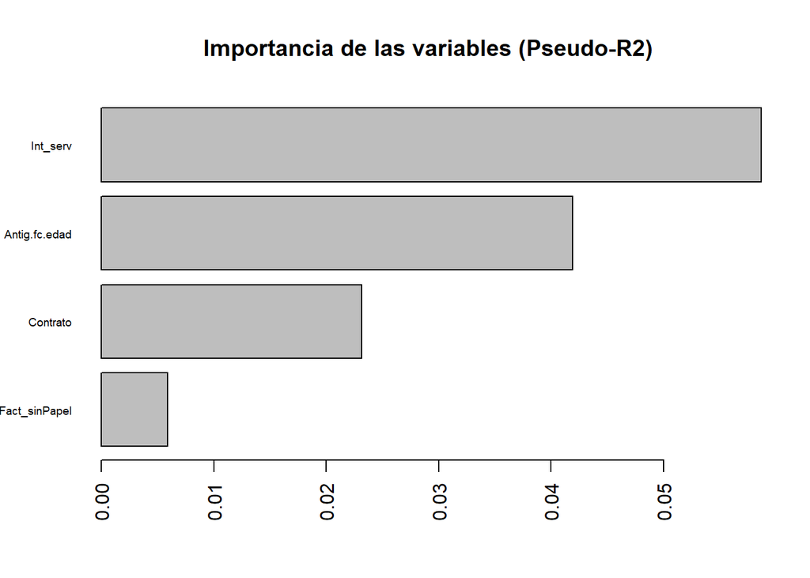

```r
# Importancia de las variables al pseudo R2
impVariablesLog(modelo12,'varObj')
```

```r
# Decimotercer modelo
modelo13 <- update(modelo12,.~.-Fact_sinPapel)
summary(modelo13)
```

```
##
## Call:
## glm(formula = varObj ~ Antig.fc.edad + Int_serv + Contrato, family = binomial,
##     data = data_train[, c(1:21, 27)])
##
## Deviance Residuals:
##     Min       1Q   Median       3Q      Max
## -1.5576  -0.6875  -0.3038   0.8400   3.2072
##
## Coefficients:
##                      Estimate Std. Error z value Pr(>|z|)
## (Intercept)         -0.286008   0.076288  -3.749 0.000178 ***
## Antig.fc.edad       -0.031992   0.002185 -14.642  < 2e-16 ***
## Int_servFiber optic  1.178193   0.085329  13.808  < 2e-16 ***
## Int_servNo          -1.036260   0.138273  -7.494 6.67e-14 ***
## ContratoOne year    -0.910992   0.119261  -7.639 2.20e-14 ***
## ContratoTwo year    -1.927482   0.209486  -9.201  < 2e-16 ***
## ---
## Signif. codes:  0 '***' 0.001 '**' 0.01 '*' 0.05 '.' 0.1 ' ' 1
##
## (Dispersion parameter for binomial family taken to be 1)
##
##     Null deviance: 5882.3  on 5082  degrees of freedom
## Residual deviance: 4394.8  on 5077  degrees of freedom
## AIC: 4406.8
##
## Number of Fisher Scoring iterations: 6
```

```r
# Consulta de los valores de pseudo R2
pseudoR2(modelo13, data_train, "varObj")
```

```
## [1] 0.252884
```

```r
pseudoR2(modelo13, data_test, "varObj")
```

```
## [1] 0.2499529
```

```r
# Número de parámetros
modelo13$rank
```

```
## [1] 6
```

```r
# Factor de inflación de la varianza estabilizado
car::vif(modelo13)
```

```
##                   GVIF Df GVIF^(1/(2*Df))
## Antig.fc.edad 1.351892  1        1.162709
## Int_serv      1.107204  2        1.025786
## Contrato      1.264063  2        1.060333
```

```r
# Resumen modelos manuales backward

modelos_Man<-list(modeloInicial,modelo2,modelo3,modelo4,
                 modelo5,modelo6,modelo7,modelo8,
                 modelo9,modelo10,modelo11, modelo12, modelo13)

# Saco los parametros de los modelos
modelos_Par<-c(modeloInicial$rank,modelo2$rank,modelo3$rank,modelo4$rank,
                 modelo5$rank,modelo6$rank,modelo7$rank,modelo8$rank,
                 modelo9$rank,modelo10$rank,modelo11$rank, modelo12$rank, modelo13$rank)

# Saco los pseudoR
psR_Man<-lapply(modelos_Man,pseudoR2,data_test,"varObj")

# Saco los VIF
vif_Man<-lapply(modelos_Man,car::vif)

# Para calcular los VIF máximos
vifMAx_Man<- c()
for (i in 1:length(vif_Man)){
  if (class(vif_Man[[i]])=='numeric'){
    vifMAx_Man[i]=max(vif_Man[[i]])
  } else{
    vifMAx_Man[i]=max(vif_Man[[i]][,3])
  }
}

tabla_modelos <- tibble(
  Modelo = c('modeloInicial','modelo2','modelo3','modelo4',
                 'modelo5','modelo6','modelo7','modelo8',
                 'modelo9','modelo10','modelo11', 'modelo12',
                 'modelo13'),
  Parametros=modelos_Par,
  pseudoR= unlist(psR_Man),
  VIF_max=vifMAx_Man)

tibble(tabla_modelos)
```

```
## # A tibble: 13 x 4
##    Modelo        Parametros pseudoR VIF_max
##    <chr>              <int>   <dbl>   <dbl>
##  1 modeloInicial         24   0.280    3.20
##  2 modelo2               17   0.280    1.34
##  3 modelo3               16   0.277    1.34
##  4 modelo4               15   0.276    1.31
##  5 modelo5               14   0.271    1.26
##  6 modelo6               13   0.269    1.25
##  7 modelo7               12   0.270    1.24
##  8 modelo8               11   0.271    1.24
##  9 modelo9               10   0.266    1.24
## 10 modelo10               9   0.260    1.21
## 11 modelo11               8   0.260    1.19
## 12 modelo12               7   0.254    1.17
## 13 modelo13               6   0.250    1.16
```

```r
modeloManual <- modelo8
```

## Selección de variables clásica con variables originales.

```r
null <- glm(varObj~1, data = data_train, family = binomial) #Modelo minimo
full <- glm(varObj~., data = data_train[ ,c(1:21, 27)], family = binomial) #Modelo maximo sin las transformaciones
```

```r
modeloStepAIC <- step(null, scope = list(lower = null, upper = full), direction = "both", trace = 0)
summary(modeloStepAIC)
```

```
##
## Call:
## glm(formula = varObj ~ Contrato + Int_serv + Antig.fc.edad +
##     Fact_sinPapel + Seguridad + MetodoPago + Peliculas + Soporte_tecnico +
##     Telf_serv + TV_streaming + PersCargo + VariasLineas + CopiaSeguridad +
##     Mayor65, family = binomial, data = data_train)
##
## Deviance Residuals:
##     Min       1Q   Median       3Q      Max
## -1.9160  -0.6685  -0.2955   0.7269   3.2493
##
## Coefficients:
##                                   Estimate Std. Error z value Pr(>|z|)
## (Intercept)                      -0.331707   0.160747  -2.064 0.039062 *
## ContratoOne year                 -0.773881   0.124014  -6.240 4.37e-10 ***
## ContratoTwo year                 -1.646618   0.214738  -7.668 1.75e-14 ***
## Int_servFiber optic               0.982493   0.105269   9.333  < 2e-16 ***
## Int_servNo                       -0.902637   0.157996  -5.713 1.11e-08 ***
## Antig.fc.edad                    -0.031411   0.002569 -12.229  < 2e-16 ***
## Fact_sinPapel1                    0.415107   0.086492   4.799 1.59e-06 ***
## Seguridad1                       -0.415002   0.100120  -4.145 3.40e-05 ***
## MetodoPagoNot Automatic Payments  0.349268   0.086209   4.051 5.09e-05 ***
## Peliculas1                        0.251999   0.091853   2.744 0.006079 **
## Soporte_tecnico1                 -0.350556   0.099508  -3.523 0.000427 ***
## Telf_serv1                       -0.506325   0.148491  -3.410 0.000650 ***
## TV_streaming1                     0.276344   0.092404   2.991 0.002784 **
## PersCargo1                       -0.236688   0.095049  -2.490 0.012769 *
## VariasLineas1                     0.175170   0.091182   1.921 0.054718 .
## CopiaSeguridad1                  -0.160795   0.089438  -1.798 0.072202 .
## Mayor651                          0.143577   0.100818   1.424 0.154411
## ---
## Signif. codes:  0 '***' 0.001 '**' 0.01 '*' 0.05 '.' 0.1 ' ' 1
##
## (Dispersion parameter for binomial family taken to be 1)
##
##     Null deviance: 5882.3  on 5082  degrees of freedom
## Residual deviance: 4241.6  on 5066  degrees of freedom
## AIC: 4275.6
##
## Number of Fisher Scoring iterations: 6
```

```r
psr_clas1 <- pseudoR2(modeloStepAIC, data_test, "varObj")
```

```r
modeloBackAIC <- step(full, scope = list(lower = null, upper = full), direction = "backward", trace = 0)
summary(modeloBackAIC)
```

```
##
## Call:
## glm(formula = varObj ~ Mayor65 + PersCargo + Antig.fc.edad +
##     Telf_serv + VariasLineas + Int_serv + Seguridad + CopiaSeguridad +
##     Soporte_tecnico + TV_streaming + Peliculas + Contrato + Fact_sinPapel +
##     MetodoPago, family = binomial, data = data_train[, c(1:21,
##     27)])
##
## Deviance Residuals:
##     Min       1Q   Median       3Q      Max
## -1.9160  -0.6685  -0.2955   0.7269   3.2493
##
## Coefficients:
##                                   Estimate Std. Error z value Pr(>|z|)
## (Intercept)                      -0.331707   0.160747  -2.064 0.039062 *
## Mayor651                          0.143577   0.100818   1.424 0.154411
## PersCargo1                       -0.236688   0.095049  -2.490 0.012769 *
## Antig.fc.edad                    -0.031411   0.002569 -12.229  < 2e-16 ***
## Telf_serv1                       -0.506325   0.148491  -3.410 0.000650 ***
## VariasLineas1                     0.175170   0.091182   1.921 0.054718 .
## Int_servFiber optic               0.982493   0.105269   9.333  < 2e-16 ***
## Int_servNo                       -0.902637   0.157996  -5.713 1.11e-08 ***
## Seguridad1                       -0.415002   0.100120  -4.145 3.40e-05 ***
## CopiaSeguridad1                  -0.160795   0.089438  -1.798 0.072202 .
## Soporte_tecnico1                 -0.350556   0.099508  -3.523 0.000427 ***
## TV_streaming1                     0.276344   0.092404   2.991 0.002784 **
## Peliculas1                        0.251999   0.091853   2.744 0.006079 **
## ContratoOne year                 -0.773881   0.124014  -6.240 4.37e-10 ***
## ContratoTwo year                 -1.646618   0.214738  -7.668 1.75e-14 ***
## Fact_sinPapel1                    0.415107   0.086492   4.799 1.59e-06 ***
## MetodoPagoNot Automatic Payments  0.349268   0.086209   4.051 5.09e-05 ***
## ---
## Signif. codes:  0 '***' 0.001 '**' 0.01 '*' 0.05 '.' 0.1 ' ' 1
##
## (Dispersion parameter for binomial family taken to be 1)
##
##     Null deviance: 5882.3  on 5082  degrees of freedom
## Residual deviance: 4241.6  on 5066  degrees of freedom
## AIC: 4275.6
##
## Number of Fisher Scoring iterations: 6
```

```r
psr_clas2 <- pseudoR2(modeloBackAIC, data_test, "varObj")
```

```r
modeloStepBIC <- step(null, scope = list(lower = null, upper = full), trace = 0,
                      direction = "both", k = log(nrow(data_train)))
summary(modeloStepBIC)
```

```
##
## Call:
## glm(formula = varObj ~ Contrato + Int_serv + Antig.fc.edad +
##     Fact_sinPapel + Seguridad + MetodoPago + Peliculas + Soporte_tecnico +
##     Telf_serv + TV_streaming, family = binomial, data = data_train)
##
## Deviance Residuals:
##     Min       1Q   Median       3Q      Max
## -1.8327  -0.6752  -0.2931   0.7381   3.3462
##
## Coefficients:
##                                   Estimate Std. Error z value Pr(>|z|)
## (Intercept)                      -0.425315   0.156951  -2.710 0.006731 **
## ContratoOne year                 -0.822858   0.123219  -6.678 2.42e-11 ***
## ContratoTwo year                 -1.704845   0.213831  -7.973 1.55e-15 ***
## Int_servFiber optic               1.049002   0.103092  10.175  < 2e-16 ***
## Int_servNo                       -0.904303   0.156046  -5.795 6.83e-09 ***
## Antig.fc.edad                    -0.031296   0.002405 -13.013  < 2e-16 ***
## Fact_sinPapel1                    0.435758   0.085992   5.067 4.03e-07 ***
## Seguridad1                       -0.432211   0.099790  -4.331 1.48e-05 ***
## MetodoPagoNot Automatic Payments  0.355898   0.085993   4.139 3.49e-05 ***
## Peliculas1                        0.270253   0.091427   2.956 0.003117 **
## Soporte_tecnico1                 -0.379658   0.098860  -3.840 0.000123 ***
## Telf_serv1                       -0.461933   0.144503  -3.197 0.001390 **
## TV_streaming1                     0.280720   0.091982   3.052 0.002274 **
## ---
## Signif. codes:  0 '***' 0.001 '**' 0.01 '*' 0.05 '.' 0.1 ' ' 1
##
## (Dispersion parameter for binomial family taken to be 1)
##
##     Null deviance: 5882.3  on 5082  degrees of freedom
## Residual deviance: 4258.6  on 5070  degrees of freedom
## AIC: 4284.6
##
## Number of Fisher Scoring iterations: 6
```

```r
psr_clas3 <- pseudoR2(modeloStepBIC, data_test, "varObj")
```

```r
modeloBackBIC <- step(full, scope = list(lower = null, upper = full), trace = 0,
                      direction = "backward",k = log(nrow(data_train)))
summary(modeloBackBIC)
```

```
##
## Call:
## glm(formula = varObj ~ PersCargo + Antig.fc.edad + Telf_serv +
##     Int_serv + Seguridad + Soporte_tecnico + TV_streaming + Contrato +
##     Fact_sinPapel + MetodoPago, family = binomial, data = data_train[,
##     c(1:21, 27)])
##
## Deviance Residuals:
##     Min       1Q   Median       3Q      Max
## -1.7941  -0.6705  -0.2944   0.7425   3.2662
##
## Coefficients:
##                                   Estimate Std. Error z value Pr(>|z|)
## (Intercept)                      -0.335651   0.157884  -2.126 0.033509 *
## PersCargo1                       -0.277346   0.093759  -2.958 0.003096 **
## Antig.fc.edad                    -0.029838   0.002375 -12.564  < 2e-16 ***
## Telf_serv1                       -0.465100   0.144593  -3.217 0.001297 **
## Int_servFiber optic               1.059253   0.102848  10.299  < 2e-16 ***
## Int_servNo                       -0.938791   0.155346  -6.043 1.51e-09 ***
## Seguridad1                       -0.427205   0.099823  -4.280 1.87e-05 ***
## Soporte_tecnico1                 -0.358424   0.098778  -3.629 0.000285 ***
## TV_streaming1                     0.364918   0.087320   4.179 2.93e-05 ***
## ContratoOne year                 -0.782425   0.123211  -6.350 2.15e-10 ***
## ContratoTwo year                 -1.654187   0.214366  -7.717 1.19e-14 ***
## Fact_sinPapel1                    0.436962   0.085986   5.082 3.74e-07 ***
## MetodoPagoNot Automatic Payments  0.355694   0.085971   4.137 3.51e-05 ***
## ---
## Signif. codes:  0 '***' 0.001 '**' 0.01 '*' 0.05 '.' 0.1 ' ' 1
##
## (Dispersion parameter for binomial family taken to be 1)
##
##     Null deviance: 5882.3  on 5082  degrees of freedom
## Residual deviance: 4258.5  on 5070  degrees of freedom
## AIC: 4284.5
##
## Number of Fisher Scoring iterations: 6
```

```r
psr_clas4 <- pseudoR2(modeloBackBIC, data_test, "varObj")
```

```r
# Resumen
param_Clas <- c(modeloStepAIC$rank, modeloBackAIC$rank,
modeloStepBIC$rank, modeloBackBIC$rank)

psR_Clas <- c(psr_clas1,psr_clas2,psr_clas3,psr_clas4)
tibble(Modelo = c('StepAIC','BackAIC', 'StepBIC', 'BackBIC'),
      parametros = param_Clas,
      pseudoR = psR_Clas)
```

```
## # A tibble: 4 x 3
##   Modelo  parametros pseudoR
##   <chr>        <int>   <dbl>
## 1 StepAIC         17   0.280
## 2 BackAIC         17   0.280
## 3 StepBIC         13   0.272
## 4 BackBIC         13   0.269
```

```r
modeloEP <- modeloStepBIC
```

## Selección de variables clásica con variables originales y sus interacciones.

```r
#Genero interacciones
formInt <- formulaInteracciones(todo_obj[,c(1:21, 27)], 22)
fullInt <- glm(formInt, data = data_train, family = binomial)
```

```r
modeloStepAIC_int <- step(null, scope = list(lower = null, upper = fullInt), direction = "both", trace = 0)
summary(modeloStepAIC_int)
```

```
##
## Call:
## glm(formula = varObj ~ Contrato + Int_serv + Antig.fc.edad +
##     Fact_sinPapel + Seguridad + MetodoPago + Peliculas + Soporte_tecnico +
##     Telf_serv + TV_streaming + PersCargo + CopiaSeguridad + VariasLineas +
##     FacturaTotal + Mayor65 + Contrato:Antig.fc.edad + Seguridad:Soporte_tecnico +
##     Int_serv:Telf_serv + Int_serv:TV_streaming + Fact_sinPapel:MetodoPago +
##     Antig.fc.edad:CopiaSeguridad + Int_serv:FacturaTotal + Peliculas:FacturaTotal +
##     Seguridad:TV_streaming + Telf_serv:PersCargo + PersCargo:VariasLineas +
##     Peliculas:CopiaSeguridad + Int_serv:CopiaSeguridad + Antig.fc.edad:Peliculas +
##     Telf_serv:Mayor65 + CopiaSeguridad:FacturaTotal, family = binomial,
##     data = data_train)
##
## Deviance Residuals:
##     Min       1Q   Median       3Q      Max
## -2.0768  -0.6829  -0.2871   0.6665   3.4311
##
## Coefficients: (3 not defined because of singularities)
##                                                   Estimate Std. Error z value
## (Intercept)                                      2.059e-01  2.263e-01   0.910
## ContratoOne year                                -1.586e+00  2.906e-01  -5.458
## ContratoTwo year                                -3.005e+00  7.350e-01  -4.088
## Int_servFiber optic                             -8.044e-01  7.330e-01  -1.097
## Int_servNo                                      -8.084e-01  1.979e-01  -4.085
## Antig.fc.edad                                   -2.257e-02  7.203e-03  -3.133
## Fact_sinPapel1                                   1.599e-01  1.547e-01   1.034
## Seguridad1                                      -6.904e-01  1.504e-01  -4.589
## MetodoPagoNot Automatic Payments                 4.274e-02  1.556e-01   0.275
## Peliculas1                                       2.883e-01  1.498e-01   1.924
## Soporte_tecnico1                                -4.425e-01  1.204e-01  -3.677
## Telf_serv1                                      -6.346e-01  1.856e-01  -3.419
## TV_streaming1                                   -1.049e-01  1.850e-01  -0.567
## PersCargo1                                      -6.153e-01  3.083e-01  -1.996
## CopiaSeguridad1                                 -7.921e-01  2.198e-01  -3.603
## VariasLineas1                                    3.505e-01  1.059e-01   3.311
## FacturaTotal                                    -3.076e-04  1.324e-04  -2.323
## Mayor651                                         6.160e-01  3.174e-01   1.941
## ContratoOne year:Antig.fc.edad                   2.325e-02  6.489e-03   3.583
## ContratoTwo year:Antig.fc.edad                   2.824e-02  1.228e-02   2.301
## Seguridad1:Soporte_tecnico1                      4.683e-01  2.125e-01   2.204
```

[output cut: 53 more lines]

```
## Int_servFiber optic:CopiaSeguridad1             0.023272 *
## Int_servNo:CopiaSeguridad1                            NA
## Antig.fc.edad:Peliculas1                        0.052852 .
## Telf_serv1:Mayor651                             0.129408
## CopiaSeguridad1:FacturaTotal                    0.138405
## ---
## Signif. codes:  0 '***' 0.001 '**' 0.01 '*' 0.05 '.' 0.1 ' ' 1
##
## (Dispersion parameter for binomial family taken to be 1)
##
##     Null deviance: 5882.3  on 5082  degrees of freedom
## Residual deviance: 4144.7  on 5047  degrees of freedom
## AIC: 4216.7
##
## Number of Fisher Scoring iterations: 7
```

```r
psr_clas1_int <- pseudoR2(modeloStepAIC_int, data_test, "varObj")
```

```r
modeloStepBIC_int <- step(null, scope=list(lower = null, upper = fullInt),
                          direction = "both",k = log(nrow(data_train)), trace = 0)
summary(modeloStepBIC_int)
```

```
##
## Call:
## glm(formula = varObj ~ Contrato + Int_serv + Antig.fc.edad +
##     Fact_sinPapel + Seguridad + MetodoPago + Peliculas + Soporte_tecnico +
##     Telf_serv + TV_streaming + Contrato:Antig.fc.edad, family = binomial,
##     data = data_train)
##
## Deviance Residuals:
##     Min       1Q   Median       3Q      Max
## -1.8773  -0.6840  -0.2882   0.7118   3.2128
##
## Coefficients:
##                                   Estimate Std. Error z value Pr(>|z|)
## (Intercept)                      -0.308223   0.159777  -1.929 0.053721 .
## ContratoOne year                 -1.844609   0.286772  -6.432 1.26e-10 ***
## ContratoTwo year                 -3.495227   0.735392  -4.753 2.01e-06 ***
## Int_servFiber optic               1.043134   0.104007  10.029  < 2e-16 ***
## Int_servNo                       -0.852296   0.157063  -5.426 5.75e-08 ***
## Antig.fc.edad                    -0.036804   0.002697 -13.645  < 2e-16 ***
## Fact_sinPapel1                    0.431798   0.086567   4.988 6.10e-07 ***
## Seguridad1                       -0.424635   0.100059  -4.244 2.20e-05 ***
## MetodoPagoNot Automatic Payments  0.347103   0.086322   4.021 5.79e-05 ***
## Peliculas1                        0.286891   0.092222   3.111 0.001865 **
## Soporte_tecnico1                 -0.371078   0.099080  -3.745 0.000180 ***
## Telf_serv1                       -0.483243   0.146261  -3.304 0.000953 ***
## TV_streaming1                     0.293156   0.092762   3.160 0.001576 **
## ContratoOne year:Antig.fc.edad    0.027238   0.006329   4.304 1.68e-05 ***
## ContratoTwo year:Antig.fc.edad    0.036148   0.012198   2.963 0.003042 **
## ---
## Signif. codes:  0 '***' 0.001 '**' 0.01 '*' 0.05 '.' 0.1 ' ' 1
##
## (Dispersion parameter for binomial family taken to be 1)
##
##     Null deviance: 5882.3  on 5082  degrees of freedom
## Residual deviance: 4231.2  on 5068  degrees of freedom
## AIC: 4261.2
##
## Number of Fisher Scoring iterations: 6
```

```r
psr_clas2_int <- pseudoR2(modeloStepBIC_int, data_test, "varObj")
```

```r
# Resumen
param_Clas <- c(modeloStepAIC_int$rank, modeloStepBIC_int$rank)

psR_Clas <- c(psr_clas1_int,psr_clas2_int)
tibble(Modelo = c('StepAIC_int', 'StepBIC_int'),
      parametros = param_Clas,
      pseudoR = psR_Clas)
```

```
## # A tibble: 2 x 3
##   Modelo      parametros pseudoR
##   <chr>            <int>   <dbl>
## 1 StepAIC_int         36   0.275
## 2 StepBIC_int         15   0.278
```

## Selección de variables clásica con variables originales y transformaciones de las variables continuas.

```r
fullT <- glm(varObj~., data = data_train, family = binomial)
```

```r
modeloStepAIC_trans <- step(null, scope = list(lower = null, upper = fullT), trace = 0, direction = "both")
summary(modeloStepAIC_trans)
```

```
##
## Call:
## glm(formula = varObj ~ Contrato + Int_serv + raiz4FacturaTotal +
##     TV_streaming + Fact_sinPapel + Peliculas + VariasLineas +
##     Seguridad + MetodoPago + Soporte_tecnico + PersCargo + Telf_serv +
##     Mayor65, family = binomial, data = data_train)
##
## Deviance Residuals:
##     Min       1Q   Median       3Q      Max
## -2.0627  -0.6710  -0.2905   0.6135   3.2063
##
## Coefficients:
##                                  Estimate Std. Error z value Pr(>|z|)
## (Intercept)                       0.86242    0.19160   4.501 6.76e-06 ***
## ContratoOne year                 -0.69883    0.12455  -5.611 2.01e-08 ***
## ContratoTwo year                 -1.72973    0.21232  -8.147 3.74e-16 ***
## Int_servFiber optic               1.23503    0.11044  11.183  < 2e-16 ***
## Int_servNo                       -1.34339    0.16119  -8.334  < 2e-16 ***
## raiz4FacturaTotal                -3.11086    0.20178 -15.417  < 2e-16 ***
## TV_streaming1                     0.43887    0.09546   4.597 4.28e-06 ***
## Fact_sinPapel1                    0.43995    0.08810   4.994 5.91e-07 ***
## Peliculas1                        0.42344    0.09506   4.454 8.42e-06 ***
## VariasLineas1                     0.35759    0.09535   3.750 0.000177 ***
## Seguridad1                       -0.30678    0.10146  -3.024 0.002496 **
## MetodoPagoNot Automatic Payments  0.26985    0.08742   3.087 0.002024 **
## Soporte_tecnico1                 -0.25460    0.10067  -2.529 0.011435 *
## PersCargo1                       -0.19275    0.09630  -2.002 0.045324 *
## Telf_serv1                       -0.31785    0.15046  -2.113 0.034642 *
## Mayor651                          0.19582    0.10166   1.926 0.054091 .
## ---
## Signif. codes:  0 '***' 0.001 '**' 0.01 '*' 0.05 '.' 0.1 ' ' 1
##
## (Dispersion parameter for binomial family taken to be 1)
##
##     Null deviance: 5882.3  on 5082  degrees of freedom
## Residual deviance: 4163.3  on 5067  degrees of freedom
## AIC: 4195.3
##
## Number of Fisher Scoring iterations: 6
```

```r
psr_clas1_trans <- pseudoR2(modeloStepAIC_trans, data_test, "varObj")
```

```r
modeloStepBIC_trans <- step(null, scope = list(lower = null, upper = fullT),
                            trace = 0, direction = "both",k = log(nrow(data_train)))
summary(modeloStepBIC_trans)
```

```
##
## Call:
## glm(formula = varObj ~ Contrato + Int_serv + raiz4FacturaTotal +
##     TV_streaming + Fact_sinPapel + Peliculas + VariasLineas +
##     Seguridad + MetodoPago, family = binomial, data = data_train)
##
## Deviance Residuals:
##     Min       1Q   Median       3Q      Max
## -2.0927  -0.6782  -0.2950   0.6053   3.1885
##
## Coefficients:
##                                  Estimate Std. Error z value Pr(>|z|)
## (Intercept)                       0.58425    0.16111   3.626 0.000287 ***
## ContratoOne year                 -0.75246    0.12363  -6.086 1.15e-09 ***
## ContratoTwo year                 -1.84008    0.21011  -8.758  < 2e-16 ***
## Int_servFiber optic               1.21034    0.09874  12.257  < 2e-16 ***
## Int_servNo                       -1.41636    0.15193  -9.323  < 2e-16 ***
## raiz4FacturaTotal                -3.16990    0.19750 -16.050  < 2e-16 ***
## TV_streaming1                     0.42997    0.09485   4.533 5.82e-06 ***
## Fact_sinPapel1                    0.45544    0.08764   5.196 2.03e-07 ***
## Peliculas1                        0.43364    0.09451   4.588 4.46e-06 ***
## VariasLineas1                     0.34279    0.09281   3.693 0.000221 ***
## Seguridad1                       -0.34777    0.10074  -3.452 0.000556 ***
## MetodoPagoNot Automatic Payments  0.29133    0.08709   3.345 0.000822 ***
## ---
## Signif. codes:  0 '***' 0.001 '**' 0.01 '*' 0.05 '.' 0.1 ' ' 1
##
## (Dispersion parameter for binomial family taken to be 1)
##
##     Null deviance: 5882.3  on 5082  degrees of freedom
## Residual deviance: 4185.7  on 5071  degrees of freedom
## AIC: 4209.7
##
## Number of Fisher Scoring iterations: 6
```

```r
psr_clas2_trans <- pseudoR2(modeloStepBIC_trans, data_test, "varObj")
```

```r
# Resumen
param_Clas <- c(modeloStepAIC_trans$rank, modeloStepBIC_trans$rank)

psR_Clas <- c(psr_clas1_trans,psr_clas2_trans)
tibble(Modelo = c('StepAIC_trans', 'StepBIC_trans'),
      parametros = param_Clas,
      pseudoR = psR_Clas)
```

```
## # A tibble: 2 x 3
##   Modelo        parametros pseudoR
##   <chr>              <int>   <dbl>
## 1 StepAIC_trans         16   0.294
## 2 StepBIC_trans         12   0.290
```

```r
modeloT <- modeloStepBIC_trans
```

## Selección de variables clásica con variables originales y transformaciones de las variables continuas e interacciones.

```r
formIntT <- formulaInteracciones(todo_obj, 27)
fullIntT <- glm(formIntT, data = data_train, family = binomial)
```

```r
modeloStepAIC_transInt <- step(null, scope = list(lower = null, upper = fullIntT), trace = 0, direction = "both")
summary(modeloStepAIC_transInt)
```

```
##
## Call:
## glm(formula = varObj ~ Contrato + Int_serv + raiz4FacturaTotal +
##     TV_streaming + Fact_sinPapel + Peliculas + VariasLineas +
##     Seguridad + MetodoPago + Soporte_tecnico + Telf_serv + PersCargo +
##     Mayor65 + Contrato:raiz4FacturaTotal + Int_serv:Telf_serv +
##     Seguridad:Soporte_tecnico + Fact_sinPapel:MetodoPago + Telf_serv:Mayor65 +
##     VariasLineas:PersCargo + Telf_serv:PersCargo + Int_serv:TV_streaming +
##     TV_streaming:Mayor65 + TV_streaming:Telf_serv + Contrato:Int_serv +
##     Int_serv:Peliculas + Contrato:Peliculas, family = binomial,
##     data = data_train)
##
## Deviance Residuals:
##     Min       1Q   Median       3Q      Max
## -2.1903  -0.6667  -0.2842   0.5823   3.2092
##
## Coefficients: (3 not defined because of singularities)
##                                                 Estimate Std. Error z value
## (Intercept)                                      1.28015    0.25240   5.072
## ContratoOne year                                -1.90106    0.71414  -2.662
## ContratoTwo year                                -6.14465    2.33055  -2.637
## Int_servFiber optic                             -0.78729    0.75358  -1.045
## Int_servNo                                      -1.41667    0.17945  -7.895
## raiz4FacturaTotal                               -3.24773    0.21161 -15.348
## TV_streaming1                                    0.51904    0.26997   1.923
## Fact_sinPapel1                                   0.16472    0.15403   1.069
## Peliculas1                                       0.07752    0.18250   0.425
## VariasLineas1                                    0.43448    0.10679   4.068
## Seguridad1                                      -0.45940    0.12448  -3.690
## MetodoPagoNot Automatic Payments                -0.01427    0.15678  -0.091
## Soporte_tecnico1                                -0.37259    0.12093  -3.081
## Telf_serv1                                      -0.36940    0.20982  -1.761
## PersCargo1                                      -0.59025    0.31246  -1.889
## Mayor651                                         0.82001    0.33526   2.446
## ContratoOne year:raiz4FacturaTotal               1.35785    0.74265   1.828
## ContratoTwo year:raiz4FacturaTotal               4.37618    2.06873   2.115
## Int_servFiber optic:Telf_serv1                   1.89932    0.75479   2.516
## Int_servNo:Telf_serv1                                 NA         NA      NA
## Seguridad1:Soporte_tecnico1                      0.44642    0.21021   2.124
## Fact_sinPapel1:MetodoPagoNot Automatic Payments  0.39811    0.18401   2.164
```

[output cut: 48 more lines]

```
## ContratoTwo year:Int_servNo                     0.551742
## Int_servFiber optic:Peliculas1                  0.080152 .
## Int_servNo:Peliculas1                                 NA
## ContratoOne year:Peliculas1                     0.056985 .
## ContratoTwo year:Peliculas1                     0.672443
## ---
## Signif. codes:  0 '***' 0.001 '**' 0.01 '*' 0.05 '.' 0.1 ' ' 1
##
## (Dispersion parameter for binomial family taken to be 1)
##
##     Null deviance: 5882.3  on 5082  degrees of freedom
## Residual deviance: 4108.4  on 5049  degrees of freedom
## AIC: 4176.4
##
## Number of Fisher Scoring iterations: 7
```

```r
psr_clas1_intTrans <- pseudoR2(modeloStepAIC_transInt, data_test, "varObj")
```

```r
modeloStepBIC_transInt <- step(null, scope = list(lower = null, upper = fullIntT),
                               trace = 0, direction = "both",k = log(nrow(data_train)))
summary(modeloStepBIC_transInt)
```

```
##
## Call:
## glm(formula = varObj ~ Contrato + Int_serv + raiz4FacturaTotal +
##     TV_streaming + Fact_sinPapel + Peliculas + VariasLineas +
##     Seguridad + MetodoPago, family = binomial, data = data_train)
##
## Deviance Residuals:
##     Min       1Q   Median       3Q      Max
## -2.0927  -0.6782  -0.2950   0.6053   3.1885
##
## Coefficients:
##                                  Estimate Std. Error z value Pr(>|z|)
## (Intercept)                       0.58425    0.16111   3.626 0.000287 ***
## ContratoOne year                 -0.75246    0.12363  -6.086 1.15e-09 ***
## ContratoTwo year                 -1.84008    0.21011  -8.758  < 2e-16 ***
## Int_servFiber optic               1.21034    0.09874  12.257  < 2e-16 ***
## Int_servNo                       -1.41636    0.15193  -9.323  < 2e-16 ***
## raiz4FacturaTotal                -3.16990    0.19750 -16.050  < 2e-16 ***
## TV_streaming1                     0.42997    0.09485   4.533 5.82e-06 ***
## Fact_sinPapel1                    0.45544    0.08764   5.196 2.03e-07 ***
## Peliculas1                        0.43364    0.09451   4.588 4.46e-06 ***
## VariasLineas1                     0.34279    0.09281   3.693 0.000221 ***
## Seguridad1                       -0.34777    0.10074  -3.452 0.000556 ***
## MetodoPagoNot Automatic Payments  0.29133    0.08709   3.345 0.000822 ***
## ---
## Signif. codes:  0 '***' 0.001 '**' 0.01 '*' 0.05 '.' 0.1 ' ' 1
##
## (Dispersion parameter for binomial family taken to be 1)
##
##     Null deviance: 5882.3  on 5082  degrees of freedom
## Residual deviance: 4185.7  on 5071  degrees of freedom
## AIC: 4209.7
##
## Number of Fisher Scoring iterations: 6
```

```r
psr_clas2_intTrans <- pseudoR2(modeloStepBIC_transInt, data_test, "varObj")
```

```r
# Resumen
param_Clas <- c(modeloStepAIC_transInt$rank, modeloStepBIC_transInt$rank)

psR_Clas <- c(psr_clas1_intTrans,psr_clas2_intTrans)
tibble(Modelo = c('StepAIC_transInt', 'StepBIC_transInt'),
      parametros = param_Clas,
      pseudoR = psR_Clas)
```

```
## # A tibble: 2 x 3
##   Modelo           parametros pseudoR
##   <chr>                 <int>   <dbl>
## 1 StepAIC_transInt         34   0.297
## 2 StepBIC_transInt         12   0.290
```

## Esquema de selección aleatoria de variables.

```r
## Seleccion aleatoria

rep <- 20
prop <- 0.7
modelosGenerados<-c()
for (i in 1:rep){
  set.seed(12345+i)
  subsample <-data_train[sample(1:nrow(data_train), prop * nrow(data_train), replace = T),]
  full <- glm(formIntT, data = subsample, family = binomial)
  null <- glm(varObj~1, data = subsample, family = binomial)
  modeloAux <- step(null,scope=list(lower=null,upper=full),direction="both",trace=0,k=log(nrow(subsample)))
  modelosGenerados <- c(modelosGenerados,paste(sort(unlist(strsplit(as.character(formula(modeloAux))[3]," [+] "))),collapse = "+"))
}
(freq(modelosGenerados, sort = "dec") -> fr)
```

```
##                                                                                                                                                                                                                                    n
## Contrato+Contrato:Peliculas+CopiaSeguridad+Fact_sinPapel+Fact_sinPapel:MetodoPago+FacturaTotal+Int_serv+MetodoPago+Peliculas+Peliculas:sqrtxAntig.fc.edad+raiz4FacturaTotal+Seguridad+Soporte_tecnico+sqrtxAntig.fc.edad+Telf_serv 1
## Contrato+Contrato:Peliculas+Fact_sinPapel+Int_serv+Mayor65+Peliculas+raiz4FacturaTotal+TV_streaming                                                                                                                                1
## Contrato+Contrato:raiz4FacturaTotal+Fact_sinPapel+Int_serv+MetodoPago+Peliculas+raiz4FacturaTotal+Telf_serv+Telf_serv:Fact_sinPapel                                                                                                1
## Contrato+Fact_sinPapel+Fact_sinPapel:MetodoPago+Int_serv+MetodoPago+Peliculas+raiz4FacturaTotal                                                                                                                                    1
## Contrato+Fact_sinPapel+Fact_sinPapel:MetodoPago+Int_serv+MetodoPago+raiz4FacturaTotal+Seguridad+TV_streaming                                                                                                                       1
## Contrato+Fact_sinPapel+FacturaMes+Int_serv+MetodoPago+Peliculas+raiz4FacturaTotal+Seguridad+Soporte_tecnico                                                                                                                        1
## Contrato+Fact_sinPapel+Int_serv+Int_serv:TV_streaming+MetodoPago+MetodoPago:Fact_sinPapel+Peliculas+raiz4FacturaTotal+TV_streaming+VariasLineas                                                                                    1
## Contrato+Fact_sinPapel+Int_serv+Int_serv:VariasLineas+Peliculas+PersCargo+raiz4FacturaTotal+Seguridad+TV_streaming+VariasLineas                                                                                                    1
## Contrato+Fact_sinPapel+Int_serv+Mayor65+MetodoPago+raiz4FacturaTotal+raiz4FacturaTotal:Mayor65+Seguridad+TV_streaming+VariasLineas                                                                                                 1
## Contrato+Fact_sinPapel+Int_serv+MetodoPago+MetodoPago:Seguridad+raiz4FacturaTotal+Seguridad+TV_streaming+VariasLineas                                                                                                              1
## Contrato+Fact_sinPapel+Int_serv+MetodoPago+Peliculas+PersCargo+raiz4FacturaTotal+Seguridad+Seguridad:MetodoPago+Soporte_tecnico+TV_streaming                                                                                       1
## Contrato+Fact_sinPapel+Int_serv+MetodoPago+Peliculas+raiz4FacturaTotal+Seguridad                                                                                                                                                   1
## Contrato+Fact_sinPapel+Int_serv+MetodoPago+raiz4FacturaTotal+Seguridad+TV_streaming                                                                                                                                                1
## Contrato+Fact_sinPapel+Int_serv+MetodoPago+raiz4FacturaTotal+Seguridad+TV_streaming+VariasLineas                                                                                                                                   1
## Contrato+Fact_sinPapel+Int_serv+MetodoPago+raiz4FacturaTotal+TV_streaming                                                                                                                                                          1
## Contrato+Fact_sinPapel+Int_serv+Peliculas+PersCargo+raiz4FacturaTotal+VariasLineas                                                                                                                                                 1
```

[output cut: 46 more lines]

## Comparativa final y selección del modelo ganador

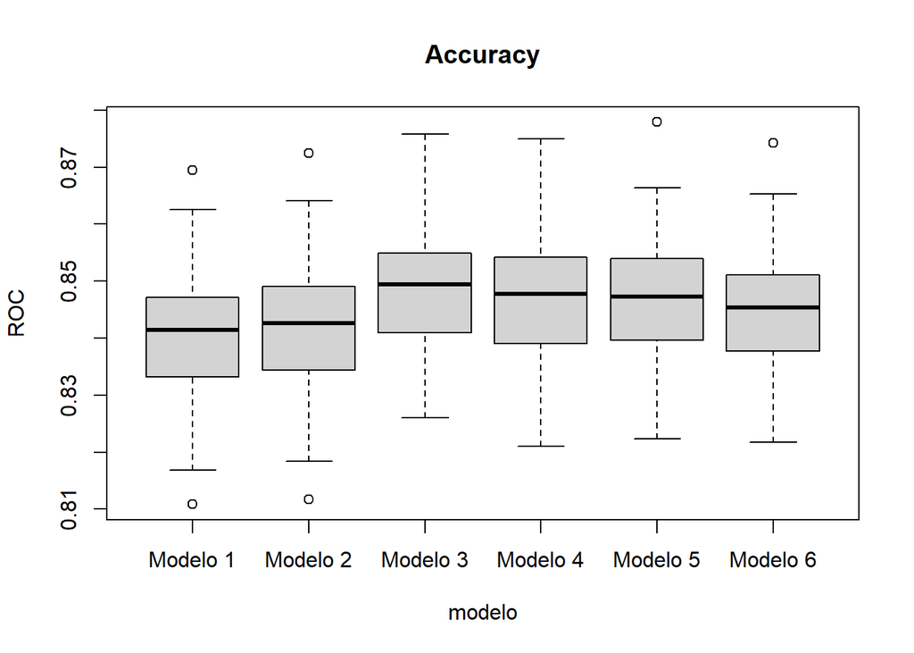

```r
total2<-c()
modelos2<-c(formula(modeloManual), formula(modeloEP), formula(modeloT),
            as.formula(paste('varObj ~', rownames(fr)[1])),
            as.formula(paste('varObj ~', rownames(fr)[2])),
            as.formula(paste('varObj ~', rownames(fr)[3])))

auxVarObj <- todo$varObj
todo$varObj <- make.names(todo$varObj)

for (i in 1:length(modelos2)){
  set.seed(1712)
  vcr<-train(as.formula(modelos2[[i]]), data = todo,
             method = "glm", family = binomial, metric = "ROC",
             trControl = trainControl(method="repeatedcv", number=5, repeats=20, summaryFunction = twoClassSummary,
                                      classProbs = TRUE,
                                      returnResamp="all")
  )
  total2<-rbind(total2,cbind(vcr$resample[,1:2],modelo=rep(paste("Modelo",i),
                                                         nrow(vcr$resample))))
}

todo$varObj <- auxVarObj
boxplot(ROC~modelo,data=total2,main="Accuracy")
```

```r
aggregate(ROC~modelo, data = total2, mean)
```

```
##     modelo       ROC
## 1 Modelo 1 0.8405377
## 2 Modelo 2 0.8417758
## 3 Modelo 3 0.8484076
## 4 Modelo 4 0.8464581
## 5 Modelo 5 0.8463671
## 6 Modelo 6 0.8446001
```

```r
aggregate(ROC~modelo, data = total2, sd)
```

```
##     modelo        ROC
## 1 Modelo 1 0.01123130
## 2 Modelo 2 0.01120747
## 3 Modelo 3 0.01032024
## 4 Modelo 4 0.01033480
## 5 Modelo 5 0.01048827
## 6 Modelo 6 0.01025867
```

```r
modeloManual$formula
```

```
## varObj ~ Antig.fc.edad + Int_serv + Seguridad + Soporte_tecnico +
##     TV_streaming + Contrato + Fact_sinPapel + MetodoPago
```

## Interpretación de parámetros del modelo ganador.

```r
modFinal <- glm(formula(modeloManual),data = todo_obj, family = binomial)

coef(modFinal)
```

```
##                      (Intercept)                    Antig.fc.edad
##                       -0.7029580                       -0.0311027
##              Int_servFiber optic                       Int_servNo
##                        0.9340172                       -1.0611609
##                       Seguridad1                 Soporte_tecnico1
##                       -0.4592007                       -0.4041569
##                    TV_streaming1                 ContratoOne year
##                        0.4213377                       -0.7793340
##                 ContratoTwo year                   Fact_sinPapel1
##                       -1.5827798                        0.4387844
## MetodoPagoNot Automatic Payments
##                        0.3312746
```

```r
logistic.display(modFinal)
```

```
##
## Logistic regression predicting varObj : 1 vs 0
##
##                                                          crude OR(95%CI)
## Antig.fc.edad (cont. var.)                               0.96 (0.96,0.96)
##
## Int_serv: ref.=DSL
##    Fiber optic                                           3.07 (2.69,3.5)
##    No                                                    0.36 (0.28,0.45)
##
## Seguridad: 1 vs 0                                        0.36 (0.32,0.42)
##
## Soporte_tecnico: 1 vs 0                                  0.4 (0.34,0.46)
##
## TV_streaming: 1 vs 0                                     1.31 (1.17,1.47)
##
## Contrato: ref.=Month-to-month
##    One year                                              0.18 (0.15,0.21)
##    Two year                                              0.04 (0.03,0.05)
##
## Fact_sinPapel: 1 vs 0                                    2.53 (2.23,2.87)
##
## MetodoPago: Not Automatic Payments vs Automatic Payments 2.73 (2.41,3.1)
##
##                                                          adj. OR(95%CI)
## Antig.fc.edad (cont. var.)                               0.97 (0.97,0.97)
##
## Int_serv: ref.=DSL
##    Fiber optic                                           2.54 (2.18,2.98)
##    No                                                    0.35 (0.27,0.45)
##
## Seguridad: 1 vs 0                                        0.63 (0.53,0.75)
##
## Soporte_tecnico: 1 vs 0                                  0.67 (0.56,0.79)
##
## TV_streaming: 1 vs 0                                     1.52 (1.31,1.78)
##
## Contrato: ref.=Month-to-month
##    One year                                              0.46 (0.37,0.57)
##    Two year                                              0.21 (0.14,0.3)
```

[output cut: 35 more lines]

```
## Soporte_tecnico: 1 vs 0                                  < 0.001
##
## TV_streaming: 1 vs 0                                     < 0.001
##
## Contrato: ref.=Month-to-month                            < 0.001
##    One year
##    Two year
##
## Fact_sinPapel: 1 vs 0                                    < 0.001
##
## MetodoPago: Not Automatic Payments vs Automatic Payments < 0.001
##
## Log-likelihood = -2674.2628
## No. of observations = 6353
## AIC value = 5370.5256
```

## Búsqueda del punto de corte óptimo para la probabilidad estimada.

```r
# Modifico la función sensEspCorte
sensEspCorte <- function(modelo,dd,nombreVar,ptoCorte,evento){

  probs <-predict(modelo,newdata=dd,type="response")

  cm<-confusionMatrix(data=factor(ifelse(probs>ptoCorte,1,0)), reference=dd[,nombreVar],positive=evento)

  c(cm$overall[1:2],cm$byClass[1:2])

}
```

```r
## Generamos una rejilla de puntos de corte
posiblesCortes<-seq(0,1,0.01)

# Aplicamos función sensEspCorte a cada punto de la rejilla
rejilla<-data.frame(t(rbind(posiblesCortes,sapply(posiblesCortes,function(x)
  sensEspCorte(modeloManual,data_test,"varObj",x,"1")))))

# Generamos Youden
rejilla$Youden<-rejilla$Sensitivity+rejilla$Specificity-1

# Generamos Index
rejilla$Index <- rejilla$Kappa+rejilla$Youden

# Puntos de corte Youden
rejilla[which.max(rejilla$Youden),]
```

```
##    posiblesCortes  Accuracy     Kappa Sensitivity Specificity    Youden
## 37           0.36 0.7771654 0.4846297   0.7507418   0.7867095 0.5374514
##       Index
## 37 1.022081
```

```r
# Punto máximo Index
rejilla[which.max(rejilla$Index),]
```

```
##    posiblesCortes Accuracy     Kappa Sensitivity Specificity   Youden    Index
## 38           0.37 0.780315 0.4875344   0.7418398   0.7942122 0.536052 1.023586
```

```r
# Predicciones en test en forma de probabilidad estimada
predTest<-predict(modeloManual,data_test, type = "response")
clasTest<-factor(ifelse(predTest>0.37,1,0))

# Matriz de confusión
confusionMatrix(clasTest,data_test$varObj, positive = '1')
```

```
## Confusion Matrix and Statistics
##
##           Reference
## Prediction   0   1
##          0 741  87
##          1 192 250
##
##                Accuracy : 0.7803
##                  95% CI : (0.7565, 0.8028)
##     No Information Rate : 0.7346
##     P-Value [Acc > NIR] : 9.872e-05
##
##                   Kappa : 0.4875
##
##  Mcnemar's Test P-Value : 4.775e-10
##
##             Sensitivity : 0.7418
##             Specificity : 0.7942
##          Pos Pred Value : 0.5656
##          Neg Pred Value : 0.8949
##              Prevalence : 0.2654
##          Detection Rate : 0.1969
##    Detection Prevalence : 0.3480
##       Balanced Accuracy : 0.7680
##
##        'Positive' Class : 1
##
```

El modelo es capaz de reconocer 741 de 933 negativos y 250 de 337 positivos.

## Predicción con el modelo ganador para los datos del test.

```r
# Lectura de los datos de test
datosFuga <- readRDS("C:/Users/96has/Documents/NTIC/6. Documentación minería de Datos y Modelización Predictiva-20211212/Tarea/FugaClientes_test.RDS")

# Cambio el nombre de la variable Antiguedad
colnames(datosFuga)[6] <- 'Antig.fc.edad'

# Cambio la variable Mayor65 que aparece como numérica y unifico categorías en MetodoPago
datosFuga$Mayor65  <- as.character(datosFuga$Mayor65)

datosFuga$MetodoPago <- car::recode(datosFuga$MetodoPago, "c('Bank transfer (automatic)', 'Credit card (automatic)')
                               = 'Automatic Payments'; c('Electronic check', 'Mailed check') = 'Not Automatic Payments'")

#Recodificación de los valores de las variables dicotómicas
datosFuga$Conyuge <- car::recode(datosFuga$Conyuge, "'Yes' = 1; 'No' = 0", as.factor = TRUE)
datosFuga$PersCargo <- car::recode(datosFuga$PersCargo, "'Yes' = 1; 'No' = 0", as.factor = TRUE)
datosFuga$Telf_serv <- car::recode(datosFuga$Telf_serv, "'Yes' = 1; 'No' = 0", as.factor = TRUE)
datosFuga$VariasLineas <- car::recode(datosFuga$VariasLineas, "'Yes' = 1; 'No' = 0", as.factor = TRUE)
datosFuga$Seguridad <- car::recode(datosFuga$Seguridad, "'Yes' = 1; 'No' = 0", as.factor = TRUE)
datosFuga$CopiaSeguridad <- car::recode(datosFuga$CopiaSeguridad, "'Yes' = 1; 'No' = 0", as.factor = TRUE)
datosFuga$Antivirus_disp <- car::recode(datosFuga$Antivirus_disp, "'Yes' = 1; 'No' = 0", as.factor = TRUE)
datosFuga$Soporte_tecnico <- car::recode(datosFuga$Soporte_tecnico, "'Yes' = 1; 'No' = 0", as.factor = TRUE)
datosFuga$TV_streaming <- car::recode(datosFuga$TV_streaming, "'Yes' = 1; 'No' = 0", as.factor = TRUE)
datosFuga$Peliculas <- car::recode(datosFuga$Peliculas, "'Yes' = 1; 'No' = 0", as.factor = TRUE)
datosFuga$Fact_sinPapel <- car::recode(datosFuga$Fact_sinPapel, "'Yes' = 1; 'No' = 0", as.factor = TRUE)

# Aplico el modelo
varObjTest <- runif(nrow(datosFuga))
inputTest <- cbind(datosFuga, Transf_Auto(Filter(is.numeric, datosFuga), varObjTest))
todoTest <- data.frame(inputTest, varObjTest)
resultadosTest <- factor(ifelse(predict(modeloManual, todoTest, type = 'response') > 0.37, 1, 0))
datosFuga$Fuga <- resultadosTest
dfTest <- datosFuga[ ,c(1, 21)]
colnames(dfTest)[2] <- 'Fuga_pred'
freq(dfTest$Fuga_pred)
```

```
##     n    % val%
## 0 472 68.4 68.4
## 1 218 31.6 31.6
```

```r
saveRDS(dfTest, 'FugaPredict_HassanChafiXavier.RDS')
```